# Technical Report: Full House Model in R

Shen Yan, Adrian Burgos Jr., Christopher Kinson, and Daniel J. Eck

Version 2

# Introduction

We will go through examples of how our Full House Model era-adjusts batting averages (BA) using the parametric method, and bWAR (Baseball-Reference Win Above Replacement), fWAR (Fangraphs Win Above Replacement), HR (Home Run), BB (Walks) for batters, bWAR, fWAR, ERA (Earned Run Average), SO (Strikeout) for pitchers using the nonparametric method. Also we provide details about how the tables and figures in the paper and supplementary materials are produced.

We first load in relevant software packages and the data. The necessary data are collected from [Baseball-Reference](https://www.baseball-reference.com/), [Fangraphs](https://www.fangraphs.com/) and Github [Chadwick](https://github.com/chadwickbureau). The details of data collection are in the Supplement Materials. The revelant datasets that involved in this technical report can be found in the Tech_report_data

For batters, each row of data consists of a player ID, a year ID, a name, a age, a league ID (lgID), a recorded number of at bats (AB), game(G), plate appearances (PA), a park-factored batting average (BA), a walk (BB), a observed hits (obs_hits), observed home run (obs_HR), a hit-by-pitch (HBP), a sacrifice bunt (SH), a sacrifice fly (SF), a park-factored hits (H), a park-factored home run (HR), a baseball-reference WAR (bWAR), a fangraph WAR (fWAR) and a size of the MLB-eligible population (pops).

For pitchers, each row of data consists of a player ID, a year ID, a name, a age, a league ID (lgID), a team ID (teamID), a recorded number of inning pitched (IP) and a game(G), a observed earned run (obs_ER), a observed home run (obs_HR), a observed hits (obs_H), a strikeout (SO), a park-factored earned run (ER), a park-factored home run (HR_PF), a park-factored hits (H_PF), a walk (BB), a hit-by-pitch (HBP), a baseball-reference WAR (bWAR), a fangraph WAR (fWAR) and a size of the MLB-eligible population (pops).

```r
rm(list=ls())
library(tidyverse)
library(orderstats)
library(Pareto)
library(doParallel)
library(splines)
library(retrosheet)
library(kableExtra)
ncores <- detectCores() - 1
years <- 1871:2022

load("bat_pit.RData")
source('source.R')
```

In this analysis we assume that BA $\stackrel{i i d}{\sim} N\left(\mu_{i}, \sigma_{i}\right)$ and that talent scores $\stackrel{i i d}{\sim} \operatorname{Pareto}(\alpha)$ where $\alpha=1.16$. We do not have any assumptions on the distribution of the baseball statistics. This choice of alpha corresponds to the Pareto principle which is casually referred to as the $80 / 20$ rule.

# Batters

In this section, our Full House Model era-adjusts batting statistics, such as bWAR, fWAR, HR, BB and BA using the nonparametric distribution measuring the components. We also apply our Full House Model to era-adjuste BA using the parametric distribution measuring the components.

## bWAR

We now try out the bWAR for batters and first we select the full-time batters. We declare the median PA after screening out individuals who batted fewer than 75 PA as our cutoff for full-time batters.

```r
batters <- bat_dat %>% select(yearID, playerID, lgID, name, age, PA, G, bWAR, pops)
cutoff <- do.call(rbind, mclapply(years, mc.cores = ncores, FUN = function(xx){
    m <- batters %>% filter(yearID == xx) %>% filter(PA >= 75)
    data.frame(thres = median(m$PA), yearID = xx)
  }))
batters <- merge(batters, cutoff, by = 'yearID')
batters <- batters %>% mutate(comp =  bWAR / G, full_time = ifelse(PA >= thres, 'Y', 'N'))
```

In the [1994 and 1995](https://en.wikipedia.org/wiki/1994%E2%80%9395_Major_League_Baseball_strike), hitters and pitchers played fewer games per season than the regular season. To deal with extreme statistics from the small sample size, we motivated a shrinkage method that adjust the raw statistics toward a global average. Our shrinkage method follows a shrinkage of ballpark effect estimates motivated from Michael Schell’s book, [Baseball’s All-Time Best Sluggers](https://www-jstor-org.proxy2.library.illinois.edu/stable/j.ctt19705ks.25?seq=8). This methods involves weighted average of raw components and league average, which is

$$\textrm{adjusted component} =
(\textrm{raw components} \times \textrm{total ABs} + 4000 \times
\textrm{league average})/(\textrm{totals AB + 4000})$$
When we use the shrinkage method to analyze our seasonal data, the shrinkage factor $4000 / (\textrm{totals AB + 4000})$ get adjusted based on fraction of 4000 to the totals AB of the MLB teams. For example,
$$\textrm{adjusted bWAR per game} = (\textrm{raw
bWAR per game} \times \textrm{game} + 7 \times \textrm{league
average})/(\textrm{game + 7})$$

```r
batters_schell <- do.call(rbind, mclapply(years, mc.cores = ncores, FUN = function(xx){
    int<- batters %>% filter(yearID == xx)
    lg_avg <- sum(int$bWAR)/sum(int$G)
    int %>% mutate(comp = (bWAR + lg_avg * 7)/(G + 7))
  }))
```

The following script computes the talent scores for bWAR per game from all batters and all seasons (1871 to 2022).

```r
batters_talent_bWAR <- do.call(rbind, mclapply(years, mc.cores = ncores, function(yy){
  talent_computing_nonpara(dataset = batters_schell, component_name = "bWAR", year = yy, ystar = thresh_fun(component = batters_schell %>% filter(full_time == 'Y', yearID == yy) %>% select(comp), component_name = 'bWAR'), alpha = 1.16) })) %>% arrange(-WAR_talent)
```

We built a common mapping environment with regard to the provided season size based on the no-strike seasons rather than utilizing one specific season from 1871 to 2022 as the projected season. To acquire era-adjusted statistics, we project the players’ talent to this common mapping environment. [Micheal Schell](https://www-jstor-org.proxy2.library.illinois.edu/stable/j.ctt19705ks.6?seq=15) inspired us to use the National League seasons from 1977 through 1989, with the exception of the 1981 strike season, as the common mapping environment. The number of teams in these seasons that we choose remains constant in order to prevent the Major League’s expansion effect. We then construct an isotonic regression model of the corresponding components on the ordered talent scores. In the common mapping environment, this model provides the association between the components and the talent scores.

We set the total number of full-time players throughout all seasons to be equal to the number of components in the common mapping environment. This is due to the fact that the more components in the common mapping environment, the $\widetilde{F}_{Y_i}(t)$ and $F_{Y_i}(t)$ are more closely. Then we select this number of components based on the quantile mapping and the quantiles of the components are equally spaced. The talent scores of the components we choose from the common mapping environment are calculated using the isotonic regression model. Now we construct the common mapping environment completely.

```r
no_strike <- batters_talent_bWAR %>%
    filter(yearID < 1990, yearID >= 1977, yearID != 1981,
           full_time == 'Y', lgID == 'NL') %>%
    arrange(WAR_talent)

t <- isoreg(no_strike$WAR_talent, no_strike$comp)
talent_new <- quantile(no_strike$WAR_talent, probs = (seq(0,250)/250))
comp_new <- as.stepfun(t)(talent_new)
```

The figure below shows the relationship between bWAR talent and bWAR per game. The black dots represent the observations from the full-time batters from the 1977 season to 1989 season with the exception of the 1981 strike season. The red dots represent the observations from the common mapping environment that we define above. Based on the figure above, the observations from the common mapping environment accurately depict the relationship between bWAR talent and bWAR per game from the 1977 season to the 1989 season with the exception of the 1981 strike season.

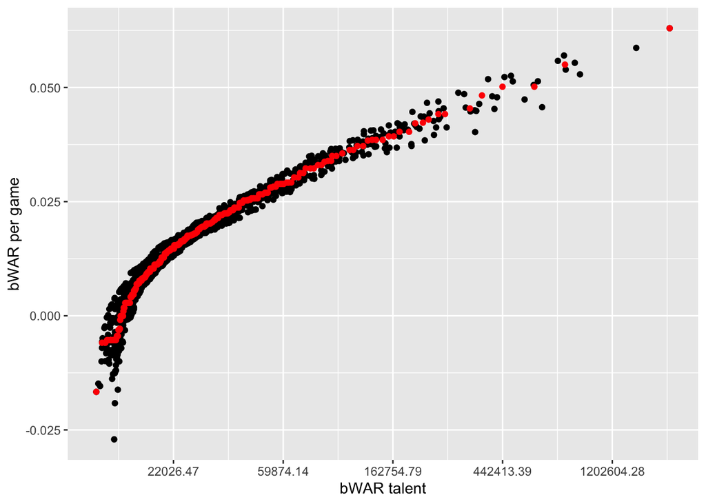

```r
mapping_envir <- data.frame(talent_new = talent_new, comp_new = comp_new)
ggplot(data = no_strike, aes(x = WAR_talent, y = comp)) + geom_point() +
  geom_point(data = mapping_envir, aes(x = talent_new, y = comp_new), color = 'red') +
  labs(x = 'bWAR talent', y = 'bWAR per game') +
  scale_x_continuous(trans='log')
```

```r
ystar <- thresh_fun(comp_new, component_name = 'bWAR')
pop_new <- round(mean(no_strike$pops))
component_name = 'bWAR'
yy <- sort(comp_new)
n <- length(yy)
ytilde <- rep(0, n + 1)
if (component_name == 'bWAR' | component_name == 'fWAR') {
    ytilde[1] <- yy[1] - (yy[2] - yy[1])
}
if (component_name == 'HR' | component_name == 'BB') {
    # since the minimal HR is greater or equal to 0.
    ytilde[1] <- 0
}
ytilde[n+1] <- yy[n] + ystar
ytilde[2:n] <- unlist(lapply(2:n, function(j){
    (yy[j]+yy[j-1])/2
}))
```

We now extend the method to compute hypothetical careers in the common mapping environment and obtain the era-adjusted statistics.

```r
career_kAB_1st <- do.call(rbind, mclapply(1:30000, function(zz){
    int <- career_talent_nonpara(dataset = batters_talent_bWAR, component_name = 'bWAR',
                         snippet = batters_talent_bWAR[zz,], alpha = 1.16)
    int
  }, mc.cores = ncores))


career_kAB_2nd <- do.call(rbind, mclapply(30001:60000, function(zz){
    int <- career_talent_nonpara(dataset = batters_talent_bWAR, component_name = 'bWAR',
                         snippet = batters_talent_bWAR[zz,], alpha = 1.16)
    int
  }, mc.cores = ncores))

career_kAB_3rd <- do.call(rbind, mclapply(60001:nrow(batters_talent_bWAR), function(zz){
    int <- career_talent_nonpara(dataset = batters_talent_bWAR, component_name = 'bWAR',
                         snippet = batters_talent_bWAR[zz,], alpha = 1.16)
    int
  }, mc.cores = ncores))

career_kAB <- rbind(career_kAB_1st, career_kAB_2nd, career_kAB_3rd)
```

Instead of using the raw G and PA in the data set, we calculate the mapped G by applying quantile mapping for the full-time hitters and non-full-time hitters separately. Quantile mapping is based on that a pth percentile player’s games in one year is equal to a pth percentile player’s games in the common mapping environment.

We also specify that worst performance of bWAR for the full time players in each season -2.

```r
## mapping statistics

mapped_quan_b_raw <- do.call(rbind, mclapply(years, function(xx){
    batters_full <- batters %>% filter(yearID == xx) %>%
      filter(full_time == 'Y') %>% arrange(-G)
    batters_less <- batters %>% filter(yearID == xx) %>%
      filter(full_time == 'N') %>% arrange(-G)

    n1 <- nrow(batters_full)
    n2 <- nrow(batters_less)

    mapped_G_full <- c()
    mapped_G_less <- c()
    for (yy in c(1977:1980, 1982:1989)) {
      batters_ref_full <- batters %>%
        filter(yearID == yy, full_time == 'Y') %>% arrange(-G)
      batters_ref_less <- batters %>%
        filter(yearID == yy, full_time == 'N') %>% arrange(-G)
      n1r <- nrow(batters_ref_full)
      n2r <- nrow(batters_ref_less)

      mapped_G_full <- cbind(mapped_G_full, approx(x = seq((n1r-1),0)/(n1r-1),
                                                   y = batters_ref_full$G,
                                                   xout = seq((n1-1),0)/(n1-1))$y)
      mapped_G_less <- cbind(mapped_G_less, approx(x = seq((n2r-1),0)/(n2r-1),
                                                   y = batters_ref_less$G,
                                                   xout = seq((n2-1),0)/(n2-1))$y)
    }

    batters_full$mapped_G <- rowMeans(mapped_G_full)
    batters_less$mapped_G <- rowMeans(mapped_G_less)


    batters_full <- batters_full %>% arrange(-PA)
    batters_less <- batters_less %>% arrange(-PA)
    mapped_PA_full <- c()
    mapped_PA_less <- c()
    for (yy in c(1977:1980, 1982:1989)) {
      batters_ref_full <- batters %>%
        filter(yearID == yy, full_time == 'Y') %>% arrange(-PA)
      batters_ref_less <- batters %>%
        filter(yearID == yy, full_time == 'N') %>% arrange(-PA)
      n1r <- nrow(batters_ref_full)
      n2r <- nrow(batters_ref_less)

      mapped_PA_full <- cbind(mapped_PA_full, approx(x = seq((n1r-1),0)/(n1r-1),
                                                     y = batters_ref_full$PA,
                                                     xout = seq((n1-1),0)/(n1-1))$y)
      mapped_PA_less <- cbind(mapped_PA_less, approx(x = seq((n2r-1),0)/(n2r-1),
                                                     y = batters_ref_less$PA,
                                                     xout = seq((n2-1),0)/(n2-1))$y)
    }

    batters_full$mapped_PA <- rowMeans(mapped_PA_full)
    batters_less$mapped_PA <- rowMeans(mapped_PA_less)

    m <- rbind(batters_full, batters_less)
    data.frame(playerID = m$playerID, yearID = m$yearID,
               mapped_G_raw = round(m$mapped_G), mapped_PA_raw = round(m$mapped_PA))

  }, mc.cores = ncores))

mapped_batters_1 <- merge(career_kAB, mapped_quan_b_raw,
                            by = c('playerID', 'yearID'))

min_refbWAR <- -2

mapped_batters_bWAR <- mapped_batters_1 %>%
    mutate(adj_bWAR = adj_comp * mapped_G_raw) %>%
    mutate(adj_bWAR = ifelse(adj_bWAR < min_refbWAR, min_refbWAR, adj_bWAR)) %>%
    mutate(mapped_G_bWAR = round(adj_bWAR / adj_comp))
```

Then we apply the same techniques for fWAR, HR, BB.

```r
batters <- bat_dat

  batters <- merge(batters, cutoff, by = 'yearID')

  batters <- batters %>% select(playerID, yearID, lgID, name, age, lgID, AB,
                                PA, obs_hits, H, thres, bWAR, pops) %>%
    mutate(comp = ifelse(AB != 0, H / AB, 0), full_time = ifelse(PA >= thres, 'Y', 'N'))

  batters_schell <- do.call(rbind, mclapply(years, mc.cores = ncores, FUN = function(xx){
    int<- batters %>% filter(yearID == xx)
    lg_avg <- sum(int$H)/sum(int$AB)
    int %>% mutate(comp = (H + lg_avg * 25)/(AB + 25))
  }))

  normality <- do.call(rbind, mclapply(years, mc.cores = ncores, FUN = function(xx){
    m <- batters_schell %>% filter(yearID == xx, full_time == 'Y') %>% pull(comp) %>% shapiro.test()
    data.frame(yearID = xx, p_value = m$p.value)
  }))

  years[which(normality$p_value <= 0.05)]
```

```
##  [1] 1876 1895 1896 1904 1908 1912 1916 1922 1924 1941 1946 1959 1961 1967 1972
## [16] 1987 1994 1997
```

Now we use both parametric and non-parametric distribution to measure the BA.

We eliminate players who had an era-adjusted bWAR or fWAR below the replacement level for more than half of their career seasons. We also set three rules to eliminate some players’ poor early and late career seasons. The three rules are

- In at least 2 consecutive seasons, the era-adjusted bWAR is below -1.5.
- In at least 2 consecutive seasons, the era-adjusted fWAR is below -1.5.
- In at least two consecutive seasons, no more than one era-adjusted bWAR or era-adjusted fWAR can be more than 0.2.

The value 0.2 is calculated from the average bWAR or fWAR of the players that disappeared from the MLB from the 1977 season to 1989 season with the exception of 1981 season.

After getting the era-adjusted statistics, we find some players’ statistics dramatically change in tails of their career, which is unrealistic in the real life. To solve it, we apply some smoothing methods to alleviate these dramatic variations, such as local polynomial regression fitting and natural cubic spline. Then natural cubic spline method has the minimal bias and is considered as the best option compared with other methods.

Also, we notice that the smoothing method could weaken player’s prime or extreme seasons. Therefore, we take the average of the smoothed era-adjusted statistics and era-adjusted statistics, which can keep player’s prime season and alleviate the dramatic changes in the tail of their career.

```r
AVG_part <- mapped_batters_AVG_nonpara %>%
    mutate(adj_AVG = round(adj_AVG, 3)) %>%
    select(yearID, playerID, name, adj_AVG)
  HR_part <- mapped_batters_HR %>%
    mutate(mapped_PA = round(mapped_PA)) %>%
    mutate(adj_HR = round(adj_HR)) %>%
    mutate(adj_AB = round(adj_AB)) %>%
    select(yearID, playerID, adj_HR, adj_AB, HBP, SF, mapped_PA)
  bWAR_part <- mapped_batters_bWAR %>%
    mutate(adj_bWAR = round(adj_bWAR, 2)) %>%
    select(yearID, playerID, adj_bWAR, mapped_G_bWAR)
  fWAR_part <- mapped_batters_fWAR %>%
    mutate(adj_fWAR = round(adj_fWAR, 2)) %>%
    select(yearID, playerID, age, adj_fWAR, mapped_G_fWAR)
  BB_part <- mapped_batters_HR %>%
    mutate(adj_BB = round(adj_BB)) %>%
    select(yearID, playerID, BB, adj_BB)
  master_batters <- merge(BB_part, merge(AVG_part,
                                         merge(HR_part, merge(bWAR_part, fWAR_part,
                                                              by = c('yearID', 'playerID')),
                                               by = c('yearID', 'playerID')),
                                         by = c('yearID', 'playerID')),
                          by = c('yearID', 'playerID'))

  master_batters <- master_batters %>%
    mutate(adj_OBP = round((adj_AVG * adj_AB + adj_BB + HBP) / (adj_AB + adj_BB + HBP + SF), 3))
  master_batters$adj_OBP[is.na(master_batters$adj_OBP)] <- 0

  master_batters_nonpara <- master_batters %>% mutate(adj_BB = ifelse(adj_BB < 0, 0, adj_BB)) %>%
    mutate(adj_AB = ifelse(mapped_PA < adj_AB, mapped_PA, adj_AB))
  master_batters_nonpara$mapped_G <- apply(master_batters_nonpara[,c(13,16)], 1, min)

  ## Batters
  batters <- master_batters_nonpara

  ## extract and remove bad players
  foo <- batters %>%
    arrange(desc(adj_AVG)) %>%
    filter(adj_AB >= 300) %>%
    dplyr::select(name, playerID, yearID, adj_AB, adj_AVG, adj_OBP, adj_HR, adj_fWAR, adj_bWAR) %>%
    mutate(adj_HR_AB = round(adj_HR/adj_AB,4))
  bar <- split(foo, as.factor(foo$playerID))
  baz <- do.call(rbind, lapply(bar, function(m){
    m[which.max(m$adj_fWAR), ]
  }))
  baz <- baz %>% arrange(adj_fWAR)
  bad_players_fWAR <- baz %>% filter(adj_fWAR < 0) %>% pull(playerID)

  baz <- do.call(rbind, lapply(bar, function(m){
    m[which.max(m$adj_bWAR), ]
  }))
  baz <- baz %>% arrange(adj_bWAR)
  bad_players_bWAR <- baz %>% filter(adj_bWAR < 0) %>% pull(playerID)
  bad_players <- union(bad_players_bWAR, bad_players_fWAR)
  batters <- batters[!batters$playerID %in% bad_players, ]

  ###### investigate anomalies ######

  ## more on base events than PAs

  # check average for minimal at bats and correct issues
  batters[batters$adj_AVG > 0 & batters$adj_AB == 0, ]$adj_AVG <- 0
  batters <- batters %>% mutate(adj_hits = round(adj_AVG * adj_AB))
  batters[batters$adj_AB > 0, ]$adj_AVG <-
    round(batters[batters$adj_AB > 0, ]$adj_hits / batters[batters$adj_AB > 0, ]$adj_AB, 3)

  ## build adjusted data set
  batters_adjusted <- batters %>%
    dplyr::select(name, playerID, age, yearID, mapped_PA, adj_AB, adj_hits, adj_HR, adj_BB,
                  adj_AVG, adj_OBP, HBP, SF, adj_bWAR, adj_fWAR)
  colnames(batters_adjusted) <- c("name", "playerID", "age", "year", "mapped_PA", "adj_AB", "adj_H",
                                  "adj_HR", "adj_BB", "adj_AVG", "adj_OBP", "HBP", "SF", "adj_bWAR", "adj_fWAR")
  batters_adjusted$playerID <- droplevels(as.factor(batters_adjusted$playerID))


  ## trim out bad players
  # first round
  foo <- split(batters_adjusted, f = batters_adjusted$playerID)
  bar <- lapply(foo, function(m){
    ifelse(m$adj_bWAR <= 0, 1, 0) + ifelse(m$adj_fWAR <= 0, 1, 0)
  })
  checker <- data.frame(pid = levels(batters_adjusted$playerID),
                        m_bad = unlist(lapply(bar, mean)),
                        len = unlist(lapply(bar, length)))
  batters_adjusted <- batters_adjusted %>%
    filter(!batters_adjusted$playerID %in% rownames(checker)[checker$m_bad == 2])
  batters_adjusted$playerID <- droplevels(batters_adjusted$playerID)

  # second round
  foo <- split(batters_adjusted, f = batters_adjusted$playerID)
  bar <- lapply(foo, function(m){
    ifelse(m$adj_bWAR <= 0, 1, 0) + ifelse(m$adj_fWAR <= 0, 1, 0)
  })
  checker <- data.frame(pid = levels(batters_adjusted$playerID),
                        m_bad = unlist(lapply(bar, mean)),
                        len = unlist(lapply(bar, length)))
  batters_adjusted <- batters_adjusted %>%
    filter(!batters_adjusted$playerID %in% rownames(checker)[checker$m_bad >= 1 & checker$len <= 2])
  batters_adjusted$playerID <- droplevels(batters_adjusted$playerID)

  # third round
  foo <- split(batters_adjusted, f = batters_adjusted$playerID)
  bar <- lapply(foo, function(m){
    min(ifelse(m$adj_bWAR <= 0, 1, 0) + ifelse(m$adj_fWAR <= 0, 1, 0))
  })
  checker <- data.frame(pid = levels(batters_adjusted$playerID),
                        m_bad = unlist(lapply(bar, mean)),
                        len = unlist(lapply(bar, length)))
  batters_adjusted <- batters_adjusted %>%
    filter(!batters_adjusted$playerID %in% rownames(checker)[checker$m_bad >= 1])
  batters_adjusted$playerID <- droplevels(batters_adjusted$playerID)

  # forth round
  foo <- split(batters_adjusted, f = batters_adjusted$playerID)
  bar <- lapply(foo, function(m){
    ifelse(m$adj_bWAR == -2, 1, 0) + ifelse(m$adj_fWAR == -2, 1, 0)
  })
  checker <- data.frame(pid = levels(batters_adjusted$playerID),
                        m_bad = unlist(lapply(bar, mean)),
                        len = unlist(lapply(bar, length)))
  batters_adjusted <- batters_adjusted %>%
    filter(!batters_adjusted$playerID %in% rownames(checker)[checker$m_bad >= 1])
  batters_adjusted$playerID <- droplevels(batters_adjusted$playerID)


  ## remove tails
  foo <- split(batters_adjusted, f = batters_adjusted$playerID)
  bar <- lapply(foo, function(m){
    bad <- ifelse(m$adj_bWAR <= 0.2, 1, 0) + ifelse(m$adj_fWAR <= 0.2, 1, 0)
    bad_tail <- sum(c(ifelse(sum(tail(bad, 2)) >= 3,1,0),
                      ifelse(sum(tail(bad, 3)) >= 5,1,0),
                      ifelse(sum(tail(bad, 4)) >= 7,1,0),
                      ifelse(sum(tail(bad, 5)) >= 9,1,0),
                      ifelse(sum(tail(bad, 6)) >= 11,1,0)))
    1:(length(bad)-bad_tail)
  })
  batters_adjusted_1 <- do.call(rbind, lapply(1:length(bar), function(j){
    foo[[j]][bar[[j]], ]
  })) %>% arrange(year)

  foo <- split(batters_adjusted_1, f = batters_adjusted_1$playerID)
  bar <- lapply(foo, function(m){
    bad <- ifelse(m$adj_fWAR <= -1.5, 1, 0)
    bad_tail <- sum(c(ifelse(sum(tail(bad, 2)) >= 2,1,0),
                      ifelse(sum(tail(bad, 3)) >= 3,1,0),
                      ifelse(sum(tail(bad, 4)) >= 4,1,0),
                      ifelse(sum(tail(bad, 5)) >= 5,1,0),
                      ifelse(sum(tail(bad, 6)) >= 6,1,0)))
    1:(length(bad)-bad_tail)
  })
  batters_adjusted_2 <- do.call(rbind, lapply(1:length(bar), function(j){
    foo[[j]][bar[[j]], ]
  })) %>% arrange(year)

  foo <- split(batters_adjusted_2, f = batters_adjusted_2$playerID)
  bar <- lapply(foo, function(m){
    bad <- ifelse(m$adj_bWAR <= -1.5, 1, 0)
    bad_tail <- sum(c(ifelse(sum(tail(bad, 2)) >= 2,1,0),
                      ifelse(sum(tail(bad, 3)) >= 3,1,0),
                      ifelse(sum(tail(bad, 4)) >= 4,1,0),
                      ifelse(sum(tail(bad, 5)) >= 5,1,0),
                      ifelse(sum(tail(bad, 6)) >= 6,1,0)))
    1:(length(bad)-bad_tail)
  })
  batters_adjusted_3 <- do.call(rbind, lapply(1:length(bar), function(j){
    foo[[j]][bar[[j]], ]
  })) %>% arrange(year)

  ## remove starts
  foo <- split(batters_adjusted_3, f = batters_adjusted_3$playerID)
  bar <- lapply(foo, function(m){
    bad <- ifelse(m$adj_bWAR <= 0, 1, 0) + ifelse(m$adj_fWAR <= 0, 1, 0)
    bad_head <- sum(c(ifelse(sum(head(bad, 1)) == 2,1,0),
                      ifelse(sum(head(bad, 2)) >= 3,1,0),
                      ifelse(sum(head(bad, 3)) >= 5,1,0),
                      ifelse(sum(head(bad, 4)) >= 7,1,0),
                      ifelse(sum(head(bad, 5)) >= 9,1,0),
                      ifelse(sum(head(bad, 6)) >= 11,1,0)))
    if (bad_head < length(bad)) {
      (bad_head + 1):length(bad)
    }
  })
  batters_adjusted_4 <- do.call(rbind, lapply(1:length(bar), function(j){
    foo[[j]][bar[[j]], ]
  })) %>% arrange(year)

  batters_adjusted_4$playerID <- droplevels(batters_adjusted_4$playerID)

  # taper down average WAR for players with small PAs
  batters_adjusted_4[batters_adjusted_4$mapped_PA <= 20, ]$adj_fWAR <-
    round(batters_adjusted_4[batters_adjusted_4$mapped_PA <= 20, ]$adj_fWAR/9,2)
  batters_adjusted_4[batters_adjusted_4$mapped_PA <= 20, ]$adj_bWAR <-
    round(batters_adjusted_4[batters_adjusted_4$mapped_PA <= 20, ]$adj_bWAR/9,2)

  batters_adjusted <- do.call(rbind, mclapply(
    split(batters_adjusted_4, f = droplevels(as.factor(batters_adjusted_4$playerID))),
    mc.cores = ncores, FUN = function(xx){
      ## natural cubic spline
      ns_AVG = lm(adj_AVG ~ ns(year, df=6), data=xx)
      nn_AVG <- predict(ns_AVG, data.frame("year"= xx$year))
      ns_HR = lm(adj_HR ~ ns(year, df=6), data=xx)
      nn_HR <- predict(ns_HR, data.frame("year"= xx$year))
      ns_BB = lm(adj_BB ~ ns(year, df=6), data=xx)
      nn_BB <- predict(ns_BB, data.frame("year"= xx$year))
      ns_bWAR = lm(adj_bWAR ~ ns(year, df=6), data=xx)
      nn_bWAR <- predict(ns_bWAR, data.frame("year"= xx$year))
      ns_fWAR = lm(adj_fWAR ~ ns(year, df=6), data=xx)
      nn_fWAR <- predict(ns_fWAR, data.frame("year"= xx$year))

      xx %>% mutate(AVG = round((adj_AVG + nn_AVG)/2, 3)) %>%
        mutate(HR = round((adj_HR + nn_HR)/2)) %>%
        mutate(BB = round((adj_BB + nn_BB)/2)) %>%
        mutate(ebWAR = round((adj_bWAR + nn_bWAR)/2, 2)) %>%
        mutate(efWAR = round((adj_fWAR + nn_fWAR)/2, 2))
    }))

  bat_season <- batters_adjusted %>%
    mutate(PA = adj_AB + BB + HBP + SF)
  bat_season[bat_season$HR >= bat_season$adj_AB, ]$HR <-
    bat_season[bat_season$HR >= bat_season$adj_AB, ]$adj_AB

 bat_season <- bat_season %>%
   dplyr::select(-c("adj_H", "adj_HR", "adj_BB", "adj_AVG", "adj_OBP", "adj_bWAR", "adj_fWAR", 'mapped_PA'))
 bat_season <- bat_season %>% mutate(OBP = round((AVG * adj_AB + BB + HBP)/(adj_AB + BB + HBP + SF), 3 )) %>%
   mutate(AVG = ifelse(AVG > 0, AVG, 0)) %>%
   mutate(HR = ifelse(HR > 0, HR, 0)) %>%
   mutate(BB = ifelse(BB > 0, BB, 0)) %>%
   mutate(OBP = ifelse(OBP > 0, OBP, 0))

 colnames(bat_season)[5] <- 'AB'
 colnames(bat_season)[8] <- 'BA'
 bat_season_nonpara <- bat_season %>% mutate(H = ceiling(AB * BA)) %>%
   mutate(BA = round(H / AB, 3)) %>%
   mutate(BA = ifelse(AB == 0, 0, BA)) %>%
   mutate(OBP = round((H+BB+HBP)/(AB+BB+HBP+SF), 3)) %>%
   mutate(OBP = ifelse(AB+BB+HBP+SF == 0, 0, OBP))

  bat_career_nonpara <- bat_season_nonpara %>% group_by(playerID) %>%
    summarise(name = unique(name),
              playerID = unique(playerID),
              PA = sum(round(PA)),
              AB = sum(AB),
              H = sum(H),
              HR = sum(round(HR)),
              BB = sum(round(BB)),
              BA = round(H/AB, 3),
              HBP = sum(HBP),
              SF = sum(SF),
              OBP = round((H + BB + HBP)/(AB + BB + HBP + SF), 3),
              ebWAR = sum(ebWAR),
              efWAR = sum(efWAR)) %>% ungroup() %>%
    arrange(desc(ebWAR))

  bat_career_nonpara <- bat_career_nonpara %>% mutate(BA = ifelse(AB == 0, 0, BA))
  bat_career_nonpara <- bat_career_nonpara %>% mutate(OBP = ifelse(AB + BB + HBP + SF == 0, 0, OBP))
```

```r
AVG_part <- mapped_batters_AVG_para %>%
    mutate(adj_AVG = round(adj_AVG, 3)) %>%
    select(yearID, playerID, name, adj_AVG)
  HR_part <- mapped_batters_HR %>%
    mutate(mapped_PA = round(mapped_PA)) %>%
    mutate(adj_HR = round(adj_HR)) %>%
    mutate(adj_AB = round(adj_AB)) %>%
    select(yearID, playerID, adj_HR, adj_AB, HBP, SF, mapped_PA)
  bWAR_part <- mapped_batters_bWAR %>%
    mutate(adj_bWAR = round(adj_bWAR, 2)) %>%
    select(yearID, playerID, adj_bWAR, mapped_G_bWAR)
  fWAR_part <- mapped_batters_fWAR %>%
    mutate(adj_fWAR = round(adj_fWAR, 2)) %>%
    select(yearID, playerID, age, adj_fWAR, mapped_G_fWAR)
  BB_part <- mapped_batters_HR %>%
    mutate(adj_BB = round(adj_BB)) %>%
    select(yearID, playerID, BB, adj_BB)
  master_batters <- merge(BB_part, merge(AVG_part,
                                         merge(HR_part, merge(bWAR_part, fWAR_part,
                                                              by = c('yearID', 'playerID')),
                                               by = c('yearID', 'playerID')),
                                         by = c('yearID', 'playerID')),
                          by = c('yearID', 'playerID'))

  master_batters <- master_batters %>%
    mutate(adj_OBP = round((adj_AVG * adj_AB + adj_BB + HBP) / (adj_AB + adj_BB + HBP + SF), 3))
  master_batters$adj_OBP[is.na(master_batters$adj_OBP)] <- 0

  master_batters_para <- master_batters %>% mutate(adj_BB = ifelse(adj_BB < 0, 0, adj_BB)) %>%
    mutate(adj_AB = ifelse(mapped_PA < adj_AB, mapped_PA, adj_AB))
  master_batters_para$mapped_G <- apply(master_batters_para[,c(13,16)], 1, min)

  ## Batters
  batters <- master_batters_para

  ## extract and remove bad players
  foo <- batters %>%
    arrange(desc(adj_AVG)) %>%
    filter(adj_AB >= 300) %>%
    dplyr::select(name, playerID, yearID, adj_AB, adj_AVG, adj_OBP, adj_HR, adj_fWAR, adj_bWAR) %>%
    mutate(adj_HR_AB = round(adj_HR/adj_AB,4))
  bar <- split(foo, as.factor(foo$playerID))
  baz <- do.call(rbind, lapply(bar, function(m){
    m[which.max(m$adj_fWAR), ]
  }))
  baz <- baz %>% arrange(adj_fWAR)
  bad_players_fWAR <- baz %>% filter(adj_fWAR < 0) %>% pull(playerID)

  baz <- do.call(rbind, lapply(bar, function(m){
    m[which.max(m$adj_bWAR), ]
  }))
  baz <- baz %>% arrange(adj_bWAR)
  bad_players_bWAR <- baz %>% filter(adj_bWAR < 0) %>% pull(playerID)
  bad_players <- union(bad_players_bWAR, bad_players_fWAR)
  batters <- batters[!batters$playerID %in% bad_players, ]

  ###### investigate anomalies ######

  ## more on base events than PAs

  # check average for minimal at bats and correct issues
  batters[batters$adj_AVG > 0 & batters$adj_AB == 0, ]$adj_AVG <- 0
  batters <- batters %>% mutate(adj_hits = round(adj_AVG * adj_AB))
  batters[batters$adj_AB > 0, ]$adj_AVG <-
    round(batters[batters$adj_AB > 0, ]$adj_hits / batters[batters$adj_AB > 0, ]$adj_AB, 3)

  ## build adjusted data set
  batters_adjusted <- batters %>%
    dplyr::select(name, playerID, age, yearID, mapped_PA, adj_AB, adj_hits, adj_HR, adj_BB,
                  adj_AVG, adj_OBP, HBP, SF, adj_bWAR, adj_fWAR)
  colnames(batters_adjusted) <- c("name", "playerID", "age", "year", "mapped_PA", "adj_AB", "adj_H",
                                  "adj_HR", "adj_BB", "adj_AVG", "adj_OBP", "HBP", "SF", "adj_bWAR", "adj_fWAR")
  batters_adjusted$playerID <- droplevels(as.factor(batters_adjusted$playerID))


  ## trim out bad players
  # first round
  foo <- split(batters_adjusted, f = batters_adjusted$playerID)
  bar <- lapply(foo, function(m){
    ifelse(m$adj_bWAR <= 0, 1, 0) + ifelse(m$adj_fWAR <= 0, 1, 0)
  })
  checker <- data.frame(pid = levels(batters_adjusted$playerID),
                        m_bad = unlist(lapply(bar, mean)),
                        len = unlist(lapply(bar, length)))
  batters_adjusted <- batters_adjusted %>%
    filter(!batters_adjusted$playerID %in% rownames(checker)[checker$m_bad == 2])
  batters_adjusted$playerID <- droplevels(batters_adjusted$playerID)

  # second round
  foo <- split(batters_adjusted, f = batters_adjusted$playerID)
  bar <- lapply(foo, function(m){
    ifelse(m$adj_bWAR <= 0, 1, 0) + ifelse(m$adj_fWAR <= 0, 1, 0)
  })
  checker <- data.frame(pid = levels(batters_adjusted$playerID),
                        m_bad = unlist(lapply(bar, mean)),
                        len = unlist(lapply(bar, length)))
  batters_adjusted <- batters_adjusted %>%
    filter(!batters_adjusted$playerID %in% rownames(checker)[checker$m_bad >= 1 & checker$len <= 2])
  batters_adjusted$playerID <- droplevels(batters_adjusted$playerID)

  # third round
  foo <- split(batters_adjusted, f = batters_adjusted$playerID)
  bar <- lapply(foo, function(m){
    min(ifelse(m$adj_bWAR <= 0, 1, 0) + ifelse(m$adj_fWAR <= 0, 1, 0))
  })
  checker <- data.frame(pid = levels(batters_adjusted$playerID),
                        m_bad = unlist(lapply(bar, mean)),
                        len = unlist(lapply(bar, length)))
  batters_adjusted <- batters_adjusted %>%
    filter(!batters_adjusted$playerID %in% rownames(checker)[checker$m_bad >= 1])
  batters_adjusted$playerID <- droplevels(batters_adjusted$playerID)

  # forth round
  foo <- split(batters_adjusted, f = batters_adjusted$playerID)
  bar <- lapply(foo, function(m){
    ifelse(m$adj_bWAR == -2, 1, 0) + ifelse(m$adj_fWAR == -2, 1, 0)
  })
  checker <- data.frame(pid = levels(batters_adjusted$playerID),
                        m_bad = unlist(lapply(bar, mean)),
                        len = unlist(lapply(bar, length)))
  batters_adjusted <- batters_adjusted %>%
    filter(!batters_adjusted$playerID %in% rownames(checker)[checker$m_bad >= 1])
  batters_adjusted$playerID <- droplevels(batters_adjusted$playerID)


  ## remove tails
  foo <- split(batters_adjusted, f = batters_adjusted$playerID)
  bar <- lapply(foo, function(m){
    bad <- ifelse(m$adj_bWAR <= 0.2, 1, 0) + ifelse(m$adj_fWAR <= 0.2, 1, 0)
    bad_tail <- sum(c(ifelse(sum(tail(bad, 2)) >= 3,1,0),
                      ifelse(sum(tail(bad, 3)) >= 5,1,0),
                      ifelse(sum(tail(bad, 4)) >= 7,1,0),
                      ifelse(sum(tail(bad, 5)) >= 9,1,0),
                      ifelse(sum(tail(bad, 6)) >= 11,1,0)))
    1:(length(bad)-bad_tail)
  })
  batters_adjusted_1 <- do.call(rbind, lapply(1:length(bar), function(j){
    foo[[j]][bar[[j]], ]
  })) %>% arrange(year)

  foo <- split(batters_adjusted_1, f = batters_adjusted_1$playerID)
  bar <- lapply(foo, function(m){
    bad <- ifelse(m$adj_fWAR <= -1.5, 1, 0)
    bad_tail <- sum(c(ifelse(sum(tail(bad, 2)) >= 2,1,0),
                      ifelse(sum(tail(bad, 3)) >= 3,1,0),
                      ifelse(sum(tail(bad, 4)) >= 4,1,0),
                      ifelse(sum(tail(bad, 5)) >= 5,1,0),
                      ifelse(sum(tail(bad, 6)) >= 6,1,0)))
    1:(length(bad)-bad_tail)
  })
  batters_adjusted_2 <- do.call(rbind, lapply(1:length(bar), function(j){
    foo[[j]][bar[[j]], ]
  })) %>% arrange(year)

  foo <- split(batters_adjusted_2, f = batters_adjusted_2$playerID)
  bar <- lapply(foo, function(m){
    bad <- ifelse(m$adj_bWAR <= -1.5, 1, 0)
    bad_tail <- sum(c(ifelse(sum(tail(bad, 2)) >= 2,1,0),
                      ifelse(sum(tail(bad, 3)) >= 3,1,0),
                      ifelse(sum(tail(bad, 4)) >= 4,1,0),
                      ifelse(sum(tail(bad, 5)) >= 5,1,0),
                      ifelse(sum(tail(bad, 6)) >= 6,1,0)))
    1:(length(bad)-bad_tail)
  })
  batters_adjusted_3 <- do.call(rbind, lapply(1:length(bar), function(j){
    foo[[j]][bar[[j]], ]
  })) %>% arrange(year)

  ## remove starts
  foo <- split(batters_adjusted_3, f = batters_adjusted_3$playerID)
  bar <- lapply(foo, function(m){
    bad <- ifelse(m$adj_bWAR <= 0, 1, 0) + ifelse(m$adj_fWAR <= 0, 1, 0)
    bad_head <- sum(c(ifelse(sum(head(bad, 1)) == 2,1,0),
                      ifelse(sum(head(bad, 2)) >= 3,1,0),
                      ifelse(sum(head(bad, 3)) >= 5,1,0),
                      ifelse(sum(head(bad, 4)) >= 7,1,0),
                      ifelse(sum(head(bad, 5)) >= 9,1,0),
                      ifelse(sum(head(bad, 6)) >= 11,1,0)))
    if (bad_head < length(bad)) {
      (bad_head + 1):length(bad)
    }
  })
  batters_adjusted_4 <- do.call(rbind, lapply(1:length(bar), function(j){
    foo[[j]][bar[[j]], ]
  })) %>% arrange(year)

  batters_adjusted_4$playerID <- droplevels(batters_adjusted_4$playerID)

  # taper down average WAR for players with small PAs
  batters_adjusted_4[batters_adjusted_4$mapped_PA <= 20, ]$adj_fWAR <-
    round(batters_adjusted_4[batters_adjusted_4$mapped_PA <= 20, ]$adj_fWAR/9,2)
  batters_adjusted_4[batters_adjusted_4$mapped_PA <= 20, ]$adj_bWAR <-
    round(batters_adjusted_4[batters_adjusted_4$mapped_PA <= 20, ]$adj_bWAR/9,2)

  batters_adjusted <- do.call(rbind, mclapply(
    split(batters_adjusted_4, f = droplevels(as.factor(batters_adjusted_4$playerID))),
    mc.cores = ncores, FUN = function(xx){
      ## natural cubic spline
      ns_AVG = lm(adj_AVG ~ ns(year, df=6), data=xx)
      nn_AVG <- predict(ns_AVG, data.frame("year"= xx$year))
      ns_HR = lm(adj_HR ~ ns(year, df=6), data=xx)
      nn_HR <- predict(ns_HR, data.frame("year"= xx$year))
      ns_BB = lm(adj_BB ~ ns(year, df=6), data=xx)
      nn_BB <- predict(ns_BB, data.frame("year"= xx$year))
      ns_bWAR = lm(adj_bWAR ~ ns(year, df=6), data=xx)
      nn_bWAR <- predict(ns_bWAR, data.frame("year"= xx$year))
      ns_fWAR = lm(adj_fWAR ~ ns(year, df=6), data=xx)
      nn_fWAR <- predict(ns_fWAR, data.frame("year"= xx$year))

      xx %>% mutate(AVG = round((adj_AVG + nn_AVG)/2, 3)) %>%
        mutate(HR = round((adj_HR + nn_HR)/2)) %>%
        mutate(BB = round((adj_BB + nn_BB)/2)) %>%
        mutate(ebWAR = round((adj_bWAR + nn_bWAR)/2, 2)) %>%
        mutate(efWAR = round((adj_fWAR + nn_fWAR)/2, 2))
    }))

  bat_season <- batters_adjusted %>%
    mutate(PA = adj_AB + BB + HBP + SF)
  bat_season[bat_season$HR >= bat_season$adj_AB, ]$HR <-
    bat_season[bat_season$HR >= bat_season$adj_AB, ]$adj_AB

 bat_season <- bat_season %>%
   dplyr::select(-c("adj_H", "adj_HR", "adj_BB", "adj_AVG", "adj_OBP", "adj_bWAR", "adj_fWAR", 'mapped_PA'))
 bat_season <- bat_season %>% mutate(OBP = round((AVG * adj_AB + BB + HBP)/(adj_AB + BB + HBP + SF), 3 )) %>%
   mutate(AVG = ifelse(AVG > 0, AVG, 0)) %>%
   mutate(HR = ifelse(HR > 0, HR, 0)) %>%
   mutate(BB = ifelse(BB > 0, BB, 0)) %>%
   mutate(OBP = ifelse(OBP > 0, OBP, 0))

 colnames(bat_season)[5] <- 'AB'
 colnames(bat_season)[8] <- 'BA'
 bat_season_para <- bat_season %>% mutate(H = ceiling(AB * BA)) %>%
   mutate(BA = round(H / AB, 3)) %>%
   mutate(BA = ifelse(AB == 0, 0, BA)) %>%
   mutate(OBP = round((H+BB+HBP)/(AB+BB+HBP+SF), 3)) %>%
   mutate(OBP = ifelse(AB+BB+HBP+SF == 0, 0, OBP))

  bat_career_para <- bat_season_para %>% group_by(playerID) %>%
    summarise(name = unique(name),
              playerID = unique(playerID),
              PA = sum(round(PA)),
              AB = sum(AB),
              H = sum(H),
              HR = sum(round(HR)),
              BB = sum(round(BB)),
              BA = round(H/AB, 3),
              HBP = sum(HBP),
              SF = sum(SF),
              OBP = round((H + BB + HBP)/(AB + BB + HBP + SF), 3),
              ebWAR = sum(ebWAR),
              efWAR = sum(efWAR)) %>% ungroup() %>%
    arrange(desc(ebWAR))

  bat_career_para <- bat_career_para %>% mutate(BA = ifelse(AB == 0, 0, BA))
  bat_career_para <- bat_career_para %>% mutate(OBP = ifelse(AB + BB + HBP + SF == 0, 0, OBP))
```

The career results for batters uses non-parametric distribution measuring the BA with top 15 bWAR batting leaders.

| playerID | name | PA | AB | H | HR | BB | BA | HBP | SF | OBP | ebWAR | efWAR |
| --- | --- | --- | --- | --- | --- | --- | --- | --- | --- | --- | --- | --- |
| bondsba01 | Barry Bonds | 12741 | 10191 | 3030 | 664 | 2353 | 0.297 | 106 | 91 | 0.431 | 153.49 | 146.98 |
| mayswi01 | Willie Mays | 12813 | 11166 | 3469 | 583 | 1512 | 0.311 | 44 | 91 | 0.392 | 144.27 | 135.99 |
| aaronha01 | Henry Aaron | 14114 | 12558 | 3900 | 698 | 1403 | 0.311 | 32 | 121 | 0.378 | 135.24 | 127.94 |
| ruthba01 | Babe Ruth | 10829 | 8890 | 2661 | 715 | 1903 | 0.299 | 43 | 0 | 0.425 | 127.70 | 121.04 |
| rodrial01 | Alex Rodriguez | 11916 | 10320 | 3044 | 557 | 1310 | 0.295 | 176 | 110 | 0.380 | 120.20 | 110.74 |
| musiast01 | Stan Musial | 13036 | 11440 | 3565 | 500 | 1490 | 0.312 | 53 | 53 | 0.392 | 117.36 | 110.58 |
| cobbty01 | Ty Cobb | 12723 | 11785 | 3761 | 262 | 848 | 0.319 | 91 | 0 | 0.369 | 114.32 | 108.91 |
| schmimi01 | Mike Schmidt | 10310 | 8516 | 2336 | 566 | 1607 | 0.274 | 79 | 108 | 0.390 | 110.65 | 107.60 |
| pujolal01 | Albert Pujols | 13202 | 11448 | 3519 | 669 | 1508 | 0.307 | 123 | 123 | 0.390 | 110.61 | 96.16 |
| willite01 | Ted Williams | 10180 | 8267 | 2580 | 505 | 1854 | 0.312 | 39 | 20 | 0.439 | 107.18 | 107.29 |
| henderi01 | Rickey Henderson | 12898 | 10642 | 3015 | 272 | 2102 | 0.283 | 90 | 64 | 0.404 | 105.62 | 101.10 |
| speaktr01 | Tris Speaker | 12002 | 10762 | 3190 | 204 | 1144 | 0.296 | 101 | 0 | 0.369 | 102.50 | 96.13 |
| morgajo02 | Joe Morgan | 11479 | 9408 | 2636 | 325 | 1935 | 0.280 | 40 | 96 | 0.402 | 100.71 | 97.21 |
| robinfr02 | Frank Robinson | 11944 | 10227 | 2996 | 537 | 1417 | 0.293 | 198 | 102 | 0.386 | 99.92 | 95.80 |
| ottme01 | Mel Ott | 11061 | 9386 | 2644 | 424 | 1611 | 0.282 | 64 | 0 | 0.390 | 97.82 | 94.68 |

The career results for batters uses parametric distribution measuring the BA with top 15 bWAR batting leaders.

| playerID | name | PA | AB | H | HR | BB | BA | HBP | SF | OBP | ebWAR | efWAR |
| --- | --- | --- | --- | --- | --- | --- | --- | --- | --- | --- | --- | --- |
| bondsba01 | Barry Bonds | 12741 | 10191 | 3026 | 664 | 2353 | 0.297 | 106 | 91 | 0.430 | 153.49 | 146.98 |
| mayswi01 | Willie Mays | 12813 | 11166 | 3454 | 583 | 1512 | 0.309 | 44 | 91 | 0.391 | 144.27 | 135.99 |
| aaronha01 | Henry Aaron | 14114 | 12558 | 3924 | 698 | 1403 | 0.312 | 32 | 121 | 0.380 | 135.24 | 127.94 |
| ruthba01 | Babe Ruth | 10829 | 8890 | 2688 | 715 | 1903 | 0.302 | 43 | 0 | 0.428 | 127.70 | 121.04 |
| rodrial01 | Alex Rodriguez | 11916 | 10320 | 3029 | 557 | 1310 | 0.294 | 176 | 110 | 0.379 | 120.20 | 110.74 |
| musiast01 | Stan Musial | 13036 | 11440 | 3581 | 500 | 1490 | 0.313 | 53 | 53 | 0.393 | 117.36 | 110.58 |
| cobbty01 | Ty Cobb | 12723 | 11785 | 3914 | 262 | 848 | 0.332 | 91 | 0 | 0.381 | 114.32 | 108.91 |
| schmimi01 | Mike Schmidt | 10310 | 8516 | 2342 | 566 | 1607 | 0.275 | 79 | 108 | 0.391 | 110.65 | 107.60 |
| pujolal01 | Albert Pujols | 13202 | 11448 | 3499 | 669 | 1508 | 0.306 | 123 | 123 | 0.389 | 110.61 | 96.16 |
| willite01 | Ted Williams | 10180 | 8267 | 2588 | 505 | 1854 | 0.313 | 39 | 20 | 0.440 | 107.18 | 107.29 |
| henderi01 | Rickey Henderson | 12898 | 10642 | 2999 | 272 | 2102 | 0.282 | 90 | 64 | 0.402 | 105.62 | 101.10 |
| speaktr01 | Tris Speaker | 12002 | 10762 | 3235 | 204 | 1144 | 0.301 | 101 | 0 | 0.373 | 102.50 | 96.13 |
| morgajo02 | Joe Morgan | 11479 | 9408 | 2641 | 325 | 1935 | 0.281 | 40 | 96 | 0.402 | 100.71 | 97.21 |
| robinfr02 | Frank Robinson | 11944 | 10227 | 3007 | 537 | 1417 | 0.294 | 198 | 102 | 0.387 | 99.92 | 95.80 |
| ottme01 | Mel Ott | 11061 | 9386 | 2653 | 424 | 1611 | 0.283 | 64 | 0 | 0.391 | 97.82 | 94.68 |

# Pitchers

We apply our Full House Model to the bWAR, fWAR, SO, ERA for pitchers using the non-parametric distribution to measure the components.

The career results for pitchers with top 15 bWAR pitching leaders.

| playerID | name | IP | ER | ERA | K | ebWAR | efWAR |
| --- | --- | --- | --- | --- | --- | --- | --- |
| clemero02 | Roger Clemens | 5440 | 1731 | 2.86 | 4718 | 143.68 | 138.71 |
| maddugr01 | Greg Maddux | 5653 | 1749 | 2.78 | 3407 | 112.42 | 119.53 |
| johnsra05 | Randy Johnson | 4724 | 1541 | 2.94 | 5034 | 109.08 | 107.55 |
| seaveto01 | Tom Seaver | 4587 | 1487 | 2.92 | 3679 | 104.81 | 91.39 |
| grovele01 | Lefty Grove | 3514 | 1102 | 2.82 | 2817 | 101.81 | 97.35 |
| blylebe01 | Bert Blyleven | 4881 | 1735 | 3.20 | 3741 | 98.00 | 101.73 |
| verlaju01 | Justin Verlander | 3887 | 1229 | 2.85 | 3112 | 96.34 | 91.58 |
| niekrph01 | Phil Niekro | 5079 | 1775 | 3.15 | 3388 | 94.68 | 77.94 |
| johnswa01 | Walter Johnson | 4789 | 1788 | 3.36 | 3925 | 92.90 | 92.67 |
| perryga01 | Gaylord Perry | 4979 | 1766 | 3.19 | 3391 | 90.23 | 94.97 |
| carltst01 | Steve Carlton | 4813 | 1629 | 3.05 | 4248 | 90.08 | 100.40 |
| spahnwa01 | Warren Spahn | 4906 | 1753 | 3.22 | 2840 | 88.93 | 70.68 |
| kershcl01 | Clayton Kershaw | 3298 | 903 | 2.46 | 2869 | 88.83 | 85.38 |
| greinza01 | Zack Greinke | 4081 | 1345 | 2.97 | 2788 | 88.40 | 78.16 |
| ryanno01 | Nolan Ryan | 5320 | 1923 | 3.25 | 6049 | 87.42 | 108.80 |

## Table 1: Top 25 greatest baseball players from different scources in the paper.

[output not shown]

## Table 2: BA rankings from different sources in the paper.

| rank | Peak in Full House | Career in Full House | Schell Method 1 | Schell Method 2 | Era-bridging Method | Raw Career |
| --- | --- | --- | --- | --- | --- | --- |
| 1 | Rod Carew | Tony Gwynn | Tony Gwynn | Tony Gwynn | Ty Cobb | Ty Cobb |
| 2 | Ichiro Suzuki | Rod Carew | Ty Cobb | Ty Cobb | Tony Gwynn | Rogers Hornsby |
| 3 | Jose Altuve | Jose Altuve | Rod Carew | Rod Carew | Ted Williams | Shoeless Joe Jackson |
| 4 | Albert Pujols | Ichiro Suzuki | Shoeless Joe Jackson | Rogers Hornsby | Wade Boggs | Lefty O’Doul |
| 5 | Joe Mauer | Miguel Cabrera | Rogers Hornsby | Stan Musial | Rod Carew | Ed Delahanty |
| 6 | Josh Hamilton | Roberto Clemente | Ted Williams | Nap Lajoie | Shoeless Jos Jackson | Tris Speaker |
| 7 | Miguel Cabrera | Ty Cobb | Honus Wagner | Shoeless Joe Jackson | Nap Lajoie | Bill Hamilton |
| 8 | Harry Walker | Joe DiMaggio | Stan Musial | Honus Wagner | Stan Musial | Ted Williams |
| 9 | José Reyes | Dale Mitchell | Wade Boggs | Ted Williams | Frank Thomas | Dan Brouthers |
| 10 | Tony Gwynn | Mike Trout | Nap Lajoie | Wade Boggs | Ed Delahanty | Babe Ruth |
| 11 | Keith Hernandez | Wade Boggs | Tris Speaker | Pete Browning | Tris Speaker | Dave Orr |
| 12 | Pete Rose | Joe Mauer | Pete Browning | Tris Speaker | Rogers Hornsby | Harry Heilmann |
| 13 | Alex Rodriguez | Buster Posey | Willie Mays | Mike Piazza | Hank Aaron | Pete Browning |
| 14 | John Olerud | Manny Mota | Dan Brouthers | Dan Brouthers | Alex Rodriguez | Willie Keeler |
| 15 | Dee Strange Gordon | Robinson Canó | Kirby Puckett | Tip O’Neill | Pete Rose | Bill Terry |
| 16 | Edgar Martinez | Stan Musial | Babe Ruth | Kirby Puckett | Honus Wagner | Lou Gehrig |
| 17 | Ken Griffey | Ted Williams | Tip O’Neill | Tony Oliva | Roberto Clements | George Sisler |
| 18 | Stan Musial | Henry Aaron | Willie Keeler | Vladimir Guerrero | George Brett | Jesse Burkett |
| 19 | Willie McGee | Matty Alou | Joe DiMaggio | Mike Donlin | Don Mattingsly | Tony Gwynn |
| 20 | Robin Yount | Freddie Freeman | Tony Oliva | Willie Keeler | Kirby Puckett | Nap Lajoie |
| 21 | Derrek Lee | Willie Mays | Jesse Burkett | Edgar Martinez | Mike Piazza | Jake Stenzel |
| 22 | Joe Torre | Al Oliver | Eddie Collins | Henry Aaron | Eddie Collins | Riggs Stephenson |
| 23 | Wade Boggs | Dee Strange Gordon | George Sisler | Derek Aaron | Edgar Martinez | Al Simmons |
| 24 | Magglio Ordonez | Daniel Murphy | Lou Gehrig | Joe DiMaggio | Paul Molitor | Cap Anson |
| 25 | Mickey Mantle | Bill Terry | Don Mattingly | Babe Ruth | Willie Mays | John McGraw |
| pre-1950 in top 10 | 1 | 3 | 7 | 7 | 6 | 10 |
| pre-1950 in top 25 | 2 | 6 | 18 | 15 | 10 | 24 |
| proportion before 1950 | 0.25 | 0.25 | 0.408 | 0.334 | 0.326 | 0.25 |
| MLB-eligible population | 1871-2011 | 1871-2011 | 1876-1984 | 1876-1997 | 1901-1996 | 1871-2011 |
| chance in top 10 | 1 in 1.06 | 1 in 2.11 | 1 in 16.41 | 1 in 50.28 | 1 in 14.43 | 1 in 1048576 |
| chance in top 10 | 1 in 1.01 | 1 in 1.61 | 1 in 631.93 | 1 in 174.84 | 1 in 3.61 | 1 in 14814472458455.6 |

## Table 3: HR rankings from different sources in the paper.

| rank | Peak in Full House | Career in Full House | Era-bridging Method | PPS detrending method | Peak in Schell | Career in Schell | Raw AB per HR |
| --- | --- | --- | --- | --- | --- | --- | --- |
| 1 | Aaron Judge | Babe Ruth | Mark McGwire | Babe Ruth | Barry Bonds | Babe Ruth | Mark McGwire |
| 2 | Mark McGwire | Mark McGwire | Juan Gonzalez | Mel Ott | Babe Ruth | Mark McGwire | Babe Ruth |
| 3 | Luke Voit | Dave Kingman | Babe Ruth | Lou Gehrig | Mark McGwire | Ted Williams | Barry Bonds |
| 4 | Albert Pujols | Willie Stargell | Dave Kingman | Jimmie Foxx | Buck Frecman | Barry Bonds | Jim Thome |
| 5 | Babe Ruth | Ralph Kiner | Mike Schmidt | Hank Aaron | Ed Delahanty | Mike Schmidt | Giancarlo Stanton |
| 6 | Mike Schmidt | Gorman Thomas | Harmon Killebrew | Rogers Hornsby | Tim Jordan | Lou Gehrig | Ralph Kiner |
| 7 | Willie Stargell | Mike Schmidt | Frank Thomas | Cy Williams | Willie Stargell | Harmon Killebrew | Harmon Killebrew |
| 8 | David Ortiz | David Ortiz | Jose Canseco | Barry Bonds | Rogers Hornsby | Jimmie Foxx | Sammy Sosa |
| 9 | Eddie Mathews | Barry Bonds | Ron Kittle | Willie Mays | Jim Thome | Dave Kingman | Ted Williams |
| 10 | Gorman Thomas | Harmon Killebrew | Willie Stargell | Ted Williams | Dave Kingman | Reggic Jackson | Manny Ramirez |
| 11 | Khris Davis | Jimmie Foxx | Willie McCovey | Reggie Jackson | Roy Sievers | Bill Nicholson | Mike Trout |
| 12 | José Bautista | Willie McCovey | Darryl Strawberry | Mike Schmidt | Jeff Bagwell | Mickey Mantle | Adam Dunn |
| 13 | Ted Williams | Darryl Strawberry | Bo Jackson | Frank Robinson | Ted Williams | Ralph Kiner | Ryan Howard |
| 14 | Ralph Kiner | Hank Greenberg | Ted Williams | Harmon Killebrew | Kevin Mitchell | Joe DiMaggio | Juan Gonzalez |
| 15 | Frank Howard | Ted Williams | Ralph Kiner | Gavvy Cravath | Mike Schmidt | Willie Stargell | Dave Kingman |
| 16 | Adrián González | Mickey Mantle | Pat Seerey | Honus Wagner | Lou Gehrig | Hack Wilson | Russell Branyan |
| 17 | Willie Mays | Jose Canseco | Reggie Jackson | Willie McCovey | Fred Dunlap | Rogers Hornsby | Mickey Mantle |
| 18 | Dave Kingman | Lou Gehrig | Ken Griffey | Harry Stovey | Harry Stovey | Darryl Strawberry | Alex Rodriguez |
| 19 | Hank Greenberg | Ryan Howard | Albert Belle | Ken Griffey Jr. | Charlie Hickman | Willie McCovey | Jimmie Foxx |
| 20 | Jimmie Foxx | Reggie Jackson | Dick Allen | Stan Musial | Bill Nicholson | Glenn Davis | Mike Schmidt |
| 21 | Juan Gonzalez | Russell Branyan | Barry Bonds | Willie Stargell | Boog Powell | Wally Berger | Jose Canseco |
| 22 | George Foster | Manny Ramirez | Dean Palmer | Eddie Murray | Joe DiMaggio | Eddie Mathews | Albert Belle |
| 23 | Mickey Mantle | Nelson Cruz | Hank Aaron | Mark McGwire | Eddie Mathews | Harry Stovey | Khris Davis |
| 24 | Pedro Álvarez | Jim Thome | Jimmie Foxx | Mickey Mantle | Mickey Mantle | Frank Howard | Ron Kittle |
| 25 | Wally Berger | Eddie Mathews | Mike Piazza | Al Simmons | Tris Speaker | Mel Ott | Carlos Delgado |
| pre-1950 in top 10 | 1 | 2 | 1 | 7 | 5 | 4 | 3 |
| pre-1950 in top 25 | 6 | 6 | 5 | 12 | 13 | 12 | 4 |
| proportion before 1950 | 0.212 | 0.292 | 0.326 | 0.355 | 0.284 | 0.381 | 0.292 |
| MLB-eligible population | 1871-2021 | 1871-2005 | 1901-1996 | 1871-1993 | 1876-2003 | 1876-1988 | 1871-2005 |
| chance in top 10 | 1 in 1.1 | 1 in 1.19 | 1 in 1.02 | 1 in 35.45 | 1 in 8.05 | 1 in 1.76 | 1 in 1.68 |
| chance in top 10 | 1 in 2.26 | 1 in 1.28 | 1 in 1.06 | 1 in 7.31 | 1 in 92.19 | 1 in 4.84 | 1 in 1.01 |

## Table 1: OBP rankings from different sources in the Supplementary materials.

| rank | Career Full House | Schell Method | Raw Career |
| --- | --- | --- | --- |
| 1 | Mike Trout | Ted Williams | Ted Williams |
| 2 | Ted Williams | Babe Ruth | Babe Ruth |
| 3 | Joey Votto | Rogers Hornsby | John McGraw |
| 4 | Barry Bonds | Barry Bonds | Billy Hamilton |
| 5 | Babe Ruth | John McGraw | Oscar Charleston |
| 6 | Mickey Mantle | Billy Hamilton | Lou Gehrig |
| 7 | Lou Gehrig | Topsy Hartsel | Barry Bonds |
| 8 | Lance Berkman | Mel Ott | Jud Wilson |
| 9 | Freddie Freeman | Roy Thomas | Bill Joyce |
| 10 | Gene Tenace | Mickey Mantle | Rogers Hornsby |
| 11 | Frank Thomas | Wade Boggs | Ty Cobb |
| 12 | Paul Goldschmidt | Frank Thomas | Jimmie Foxx |
| 13 | Miguel Cabrera | Lou Gehrig | Tris Speaker |
| 14 | Rickey Henderson | Rickey Henderson | Eddie Collins |
| 15 | Edgar Martinez | Stan Musial | Ferris Fain |
| 16 | Wade Boggs | Edgar Martinez | Dan Brouthers |
| 17 | Joe Mauer | Ty Cobb | Max Bishop |
| 18 | Prince Fielder | Dan Brouthers | Shoeless Joe Jackson |
| 19 | Joe Morgan | Tris Speaker | Mickey Mantle |
| 20 | Jason Giambi | Joe Cunningham | Mickey Cochrane |
| 21 | Mike Hargrove | George Gore | Frank Thomas |
| 22 | Manny Ramirez | Eddie Collins | Mike Trout |
| 23 | Bobby Abreu | Ross Youngs | Edgar Martinez |
| 24 | Brian Giles | Mike Hargrove | Turkey Stearnes |
| 25 | Ken Singleton | Jeff Bagwell | Stan Musial |
| pre-1950 in top 10 | 3 | 8 | 9 |
| pre-1950 in top 25 | 3 | 16 | 19 |
| proportion before 1950 | 0.25 | 0.354 | 0.25 |
| MLB-eligible population | 1871-2011 | 1876-1993 | 1871-2011 |
| chance in top 10 | 1 in 2.11 | 1 in 191.34 | 1 in 33825.03 |
| chance in top 10 | 1 in 1.03 | 1 in 298.15 | 1 in 7867593.12 |

## Table 2: percent of seasons in which BA failed the Shapiro-Wilk test based on different p-value thresholds in the Supplementary materials.

| p_value | number_season |
| --- | --- |
| 0.05 | 0.15 |
| 0.10 | 0.23 |
| 0.20 | 0.34 |
| 0.30 | 0.38 |

## Figure 1: Histogram of the p-values from Shapiro-Wilk test of normality on the BA distribution in each season in the Supplementary materials.

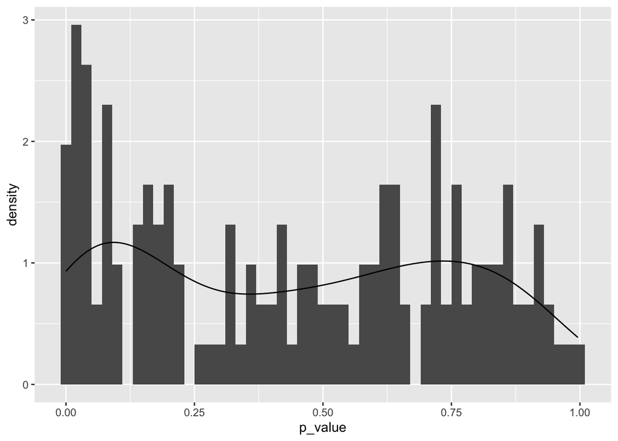

## Table 3: Top 25 BA, OBP and HR leaders in the Supplementary materials.

| rank | name | BA | name | OBP | name | HR |
| --- | --- | --- | --- | --- | --- | --- |
| 1 | Tony Gwynn | 0.341 | Mike Trout | 0.441 | Babe Ruth | 715 |
| 2 | Rod Carew | 0.33 | Ted Williams | 0.439 | Henry Aaron | 698 |
| 3 | Jose Altuve | 0.327 | Joey Votto | 0.433 | Albert Pujols | 669 |
| 4 | Ichiro Suzuki | 0.327 | Barry Bonds | 0.431 | Barry Bonds | 664 |
| 5 | Miguel Cabrera | 0.321 | Babe Ruth | 0.425 | Reggie Jackson | 590 |
| 6 | Roberto Clemente | 0.319 | Mickey Mantle | 0.418 | Willie Mays | 583 |
| 7 | Ty Cobb | 0.319 | Lou Gehrig | 0.414 | Mike Schmidt | 566 |
| 8 | Joe DiMaggio | 0.318 | Lance Berkman | 0.41 | Alex Rodriguez | 557 |
| 9 | Dale Mitchell | 0.318 | Freddie Freeman | 0.408 | Willie Stargell | 539 |
| 10 | Mike Trout | 0.318 | Gene Tenace | 0.407 | Frank Robinson | 537 |
| 11 | Wade Boggs | 0.315 | Frank Thomas | 0.407 | Ken Griffey Jr | 535 |
| 12 | Joe Mauer | 0.314 | Paul Goldschmidt | 0.406 | Willie McCovey | 526 |
| 13 | Buster Posey | 0.314 | Miguel Cabrera | 0.404 | David Ortiz | 517 |
| 14 | Manny Mota | 0.313 | Rickey Henderson | 0.404 | Harmon Killebrew | 516 |
| 15 | Robinson Canó | 0.312 | Edgar Martinez | 0.404 | Mickey Mantle | 508 |
| 16 | Stan Musial | 0.312 | Wade Boggs | 0.403 | Eddie Mathews | 505 |
| 17 | Ted Williams | 0.312 | Joe Mauer | 0.403 | Ted Williams | 505 |
| 18 | Henry Aaron | 0.311 | Prince Fielder | 0.402 | Eddie Murray | 504 |
| 19 | Matty Alou | 0.311 | Joe Morgan | 0.402 | Stan Musial | 500 |
| 20 | Freddie Freeman | 0.311 | Jason Giambi | 0.401 | Jimmie Foxx | 497 |
| 21 | Willie Mays | 0.311 | Mike Hargrove | 0.401 | Dave Winfield | 497 |
| 22 | Al Oliver | 0.311 | Manny Ramirez | 0.398 | Mark McGwire | 495 |
| 23 | Dee Strange Gordon | 0.31 | Bobby Abreu | 0.397 | Lou Gehrig | 488 |
| 24 | Daniel Murphy | 0.31 | Brian Giles | 0.397 | Jim Thome | 488 |
| 25 | Bill Terry | 0.31 | Ken Singleton | 0.397 | Manny Ramirez | 482 |
| pre-1950 in top 10 | 3 |  | 3 |  | 1 |  |
| pre-1950 in top 25 | 6 |  | 3 |  | 5 |  |
| proportion before 1950 | 0.25 |  | 0.25 |  | 0.292 |  |
| MLB-eligible population | 1871-2011 |  | 1871-2011 |  | 1871-2005 |  |
| chance in top 10 | 1 in 2.11 |  | 1 in 2.11 |  | 1 in 1.03 |  |
| chance in top 10 | 1 in 1.61 |  | 1 in 1.03 |  | 1 in 1.12 |  |

## Table 4: Top 25 bWAR and fWAR leaders for MLB batters in the Supplementary materials.

| rank | name | ebWAR | name | efWAR |
| --- | --- | --- | --- | --- |
| 1 | Barry Bonds | 153.49 | Barry Bonds | 146.98 |
| 2 | Willie Mays | 144.27 | Willie Mays | 135.99 |
| 3 | Henry Aaron | 135.24 | Henry Aaron | 127.94 |
| 4 | Babe Ruth | 127.7 | Babe Ruth | 121.04 |
| 5 | Alex Rodriguez | 120.2 | Alex Rodriguez | 110.74 |
| 6 | Stan Musial | 117.36 | Stan Musial | 110.58 |
| 7 | Ty Cobb | 114.32 | Ty Cobb | 108.91 |
| 8 | Mike Schmidt | 110.65 | Mike Schmidt | 107.6 |
| 9 | Albert Pujols | 110.61 | Ted Williams | 107.29 |
| 10 | Ted Williams | 107.18 | Rickey Henderson | 101.1 |
| 11 | Rickey Henderson | 105.62 | Joe Morgan | 97.21 |
| 12 | Tris Speaker | 102.5 | Albert Pujols | 96.16 |
| 13 | Joe Morgan | 100.71 | Tris Speaker | 96.13 |
| 14 | Frank Robinson | 99.92 | Frank Robinson | 95.8 |
| 15 | Mel Ott | 97.82 | Mel Ott | 94.68 |
| 16 | Rogers Hornsby | 97.15 | Rogers Hornsby | 94.32 |
| 17 | Carl Yastrzemski | 95.76 | Mickey Mantle | 93.76 |
| 18 | Cal Ripken Jr | 95.02 | Carl Yastrzemski | 93.58 |
| 19 | Lou Gehrig | 94.86 | Lou Gehrig | 92.12 |
| 20 | Mickey Mantle | 94.49 | Cal Ripken Jr | 91.15 |
| 21 | Adrián Beltré | 92.59 | Honus Wagner | 89.56 |
| 22 | Eddie Collins | 91.89 | Wade Boggs | 86.55 |
| 23 | Roberto Clemente | 90.74 | Pete Rose | 85.63 |
| 24 | Wade Boggs | 90.69 | Eddie Mathews | 85.46 |
| 25 | George Brett | 88.25 | Adrián Beltré | 84.58 |
| pre-1950 in top 10 | 4 |  | 4 |  |
| pre-1950 in top 25 | 9 |  | 9 |  |
| proportion before 1950 | 0.292 |  | 0.292 |  |
| chance in top 10 | 1 in 3.04 |  | 1 in 3.04 |  |
| chance in top 10 | 1 in 3.43 |  | 1 in 3.43 |  |

## Table 5: Top 25 IP, ERA, SO leaders in the Supplementary materials.

| rank | name | IP | name | ERA | name | SO |
| --- | --- | --- | --- | --- | --- | --- |
| 1 | Greg Maddux | 5653 | Mariano Rivera | 2.35 | Nolan Ryan | 6049 |
| 2 | Roger Clemens | 5440 | Clayton Kershaw | 2.46 | Randy Johnson | 5034 |
| 3 | Nolan Ryan | 5320 | Brandon Webb | 2.53 | Roger Clemens | 4718 |
| 4 | Phil Niekro | 5079 | Pedro Martinez | 2.62 | Steve Carlton | 4248 |
| 5 | Don Sutton | 5073 | Johan Santana | 2.67 | Walter Johnson | 3925 |
| 6 | Gaylord Perry | 4979 | Chris Sale | 2.73 | Bert Blyleven | 3741 |
| 7 | Tom Glavine | 4920 | Greg Maddux | 2.78 | Tom Seaver | 3679 |
| 8 | Warren Spahn | 4906 | Hoyt Wilhelm | 2.79 | Don Sutton | 3590 |
| 9 | Bert Blyleven | 4881 | Max Scherzer | 2.8 | Greg Maddux | 3407 |
| 10 | Steve Carlton | 4813 | Lefty Grove | 2.82 | Gaylord Perry | 3391 |
| 11 | Walter Johnson | 4789 | Roy Oswalt | 2.82 | Phil Niekro | 3388 |
| 12 | Randy Johnson | 4724 | Justin Verlander | 2.85 | Justin Verlander | 3112 |
| 13 | Tom Seaver | 4587 | Roger Clemens | 2.86 | Fergie Jenkins | 3108 |
| 14 | Tommy John | 4586 | Roy Halladay | 2.86 | John Smoltz | 3077 |
| 15 | Jamie Moyer | 4549 | Dizzy Dean | 2.89 | Bob Feller | 3074 |
| 16 | Cy Young | 4546 | Stephen Strasburg | 2.89 | Pedro Martinez | 3053 |
| 17 | Robin Roberts | 4437 | Cole Hamels | 2.92 | Curt Schilling | 3031 |
| 18 | Pete Alexander | 4358 | Tom Seaver | 2.92 | CC Sabathia | 2980 |
| 19 | Early Wynn | 4295 | Randy Johnson | 2.94 | Frank Tanana | 2845 |
| 20 | Fergie Jenkins | 4200 | Carl Hubbell | 2.95 | Warren Spahn | 2840 |
| 21 | Dennis Martinez | 4174 | Corey Kluber | 2.95 | Bob Gibson | 2837 |
| 22 | CC Sabathia | 4172 | John Smoltz | 2.95 | Lefty Grove | 2817 |
| 23 | Zack Greinke | 4081 | Sandy Koufax | 2.96 | Zack Greinke | 2788 |
| 24 | Mike Mussina | 4037 | Zack Greinke | 2.97 | Mike Mussina | 2687 |
| 25 | Jack Morris | 4027 | Steve Rogers | 2.98 | Jack Morris | 2677 |
| pre-1950 in top 10 | 1 |  | 1 |  | 1 |  |
| pre-1950 in top 25 | 6 |  | 3 |  | 4 |  |
| proportion before 1950 | 0.292 |  | 0.25 |  | 0.292 |  |
| MLB-eligible population | 1871-2005 |  | 1871-2011 |  | 1871-2005 |  |
| chance in top 10 | 1 in 1.03 |  | 1 in 1.06 |  | 1 in 1.03 |  |
| chance in top 10 | 1 in 1.28 |  | 1 in 1.03 |  | 1 in 1.04 |  |

## Table 6: Top 25 bWAR and fWAR leaders for MLB pitchers in the Supplementary materials.

| rank | name | ebWAR | name | efWAR |
| --- | --- | --- | --- | --- |
| 1 | Roger Clemens | 143.68 | Roger Clemens | 138.71 |
| 2 | Greg Maddux | 112.42 | Greg Maddux | 119.53 |
| 3 | Randy Johnson | 109.08 | Nolan Ryan | 108.8 |
| 4 | Tom Seaver | 104.81 | Randy Johnson | 107.55 |
| 5 | Lefty Grove | 101.81 | Bert Blyleven | 101.73 |
| 6 | Bert Blyleven | 98 | Steve Carlton | 100.4 |
| 7 | Justin Verlander | 96.34 | Lefty Grove | 97.35 |
| 8 | Phil Niekro | 94.68 | Gaylord Perry | 94.97 |
| 9 | Walter Johnson | 92.9 | Walter Johnson | 92.67 |
| 10 | Gaylord Perry | 90.23 | Justin Verlander | 91.58 |
| 11 | Steve Carlton | 90.08 | Tom Seaver | 91.39 |
| 12 | Warren Spahn | 88.93 | Cy Young | 85.96 |
| 13 | Zack Greinke | 88.4 | Don Sutton | 83.34 |
| 14 | Nolan Ryan | 87.42 | Pedro Martinez | 81.12 |
| 15 | Pedro Martinez | 87.12 | John Smoltz | 79.08 |
| 16 | Mike Mussina | 83.19 | Mike Mussina | 78.97 |
| 17 | Curt Schilling | 80.52 | Pete Alexander | 78.6 |
| 18 | Tom Glavine | 79.78 | Zack Greinke | 78.16 |
| 19 | Fergie Jenkins | 78.92 | Phil Niekro | 77.94 |
| 20 | Bob Gibson | 77.17 | Fergie Jenkins | 76.81 |
| 21 | Robin Roberts | 76.76 | Bob Gibson | 76.46 |
| 22 | Roy Halladay | 76.51 | Tommy John | 76 |
| 23 | CC Sabathia | 74.13 | Curt Schilling | 75.83 |
| 24 | Don Sutton | 73.38 | CC Sabathia | 75.04 |
| 25 | Rick Reuschel | 69.94 | Kevin Brown | 72.93 |
| pre-1950 in top 10 | 2 |  | 2 |  |
| pre-1950 in top 25 | 4 |  | 4 |  |
| proportion before 1950 | 0.292 |  | 0.292 |  |
| chance in top 10 | 1 in 1.19 |  | 1 in 1.19 |  |
| chance in top 10 | 1 in 1.04 |  | 1 in 1.04 |  |

## Histogram of the best 100 and 1000 players by their rookie year

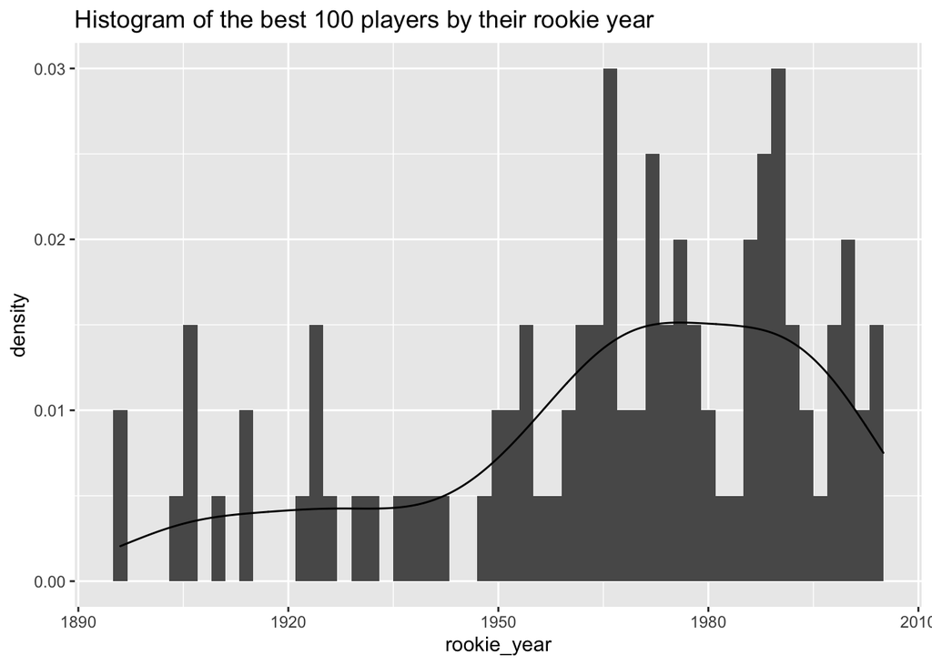

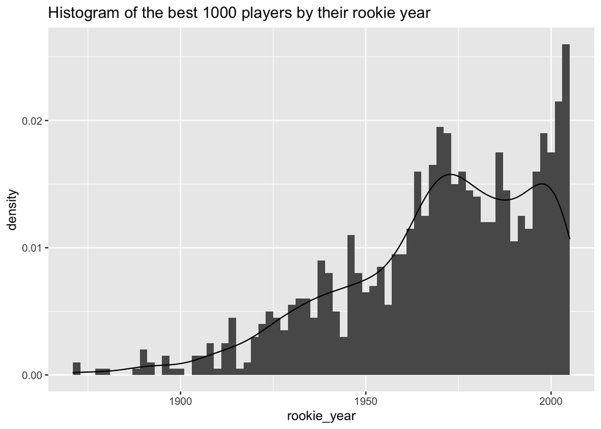

# Discussion

## Year Effect on the Talent of the Replacement-level Batters

The year effect for bWAR from the talent perspective and the era-adjusted bWAR perspective will be covered in this section.

The two figures below show that the bWAR and fWAR talent of the replacement-level batters from 1871 to 2022. The line in the plot is the smoothed line after apply natural cubic spline method. The changing pattern is the similar for the talent of the replacement-level batters and MLB-eligible population. The seasons that deviate from the smoothed line are those associated with strikes and World War II, such as 1943 - 1946, 1981, 1994, 1995 and 2020 seasons.

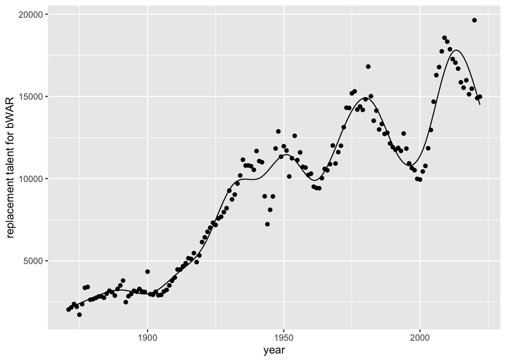

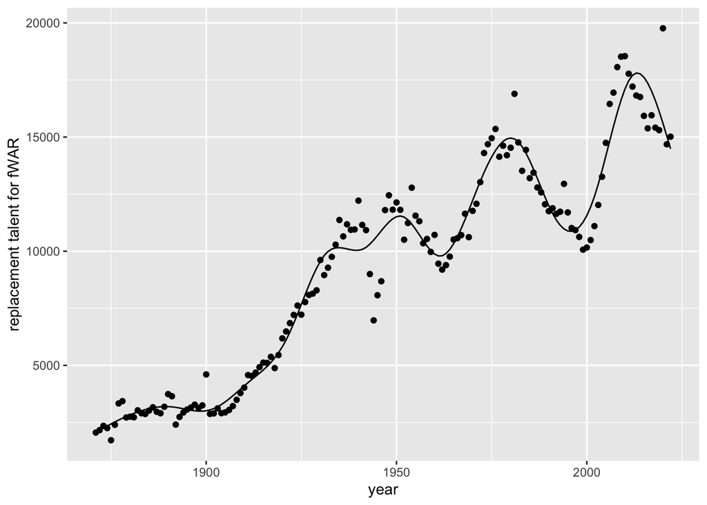

## Year Effect on the Era-adjusted WAR of the Hypothetical Batters from 2022

In this section we calculate the bWAR talent of a hypothetical 2022 hitter with 0 bWAR. Then, we compute his era-adjusted bWAR by mapping this hypothetical player to the other seasons from 1871 through 2021.

## Figure 2: Year Effect on the Era-adjusted WAR in the paper.

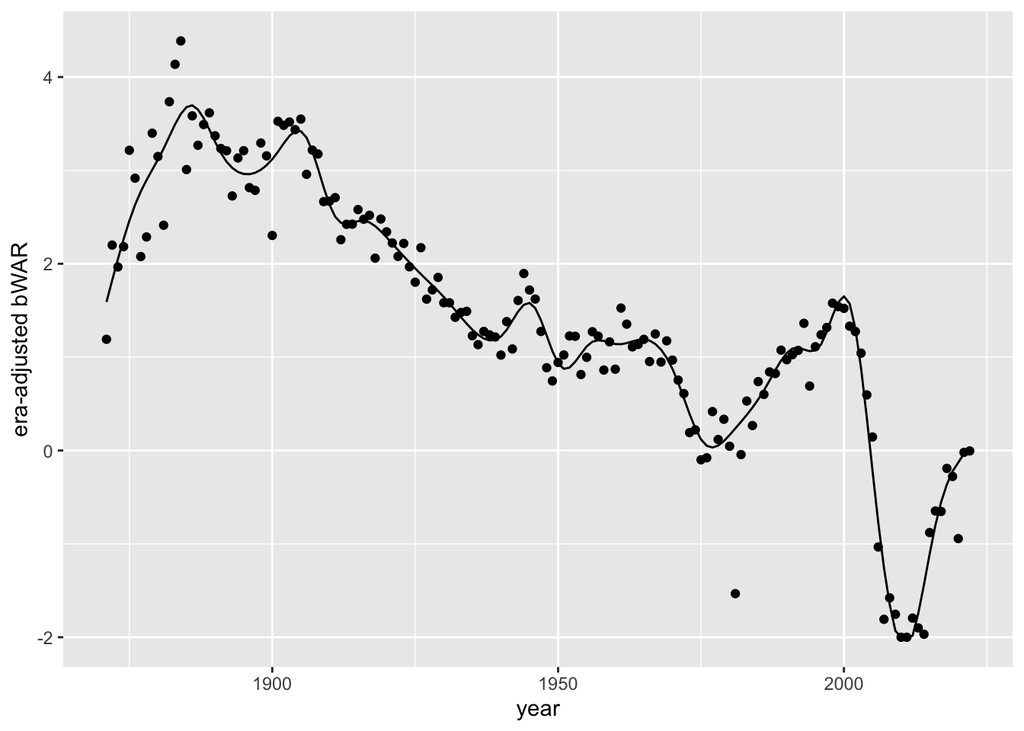

The figure above shows the era-adjusted bWAR values over time corresponding to a hypothetical batter with 0 bWAR in 2022 using the Full House Model. The fall in the mid-2000s corresponds to increase of MLB-eligible population. Despite the sharp decline in era-adjusted bWAR values in 1981 season, it is untrue that the 1981 batters with 0 bWAR would perform better than the 2022 batters. This is because the 1981 season was brief and a large number of batters underperformed replacement-level players. The problem of the sharp decline in era-adjusted bWAR values in the 1981 season is resolved when we look at the era-adjusted bWAR and era-adjusted bWAR per game of the hypothetical hitters from 2022 with 2 bWAR.

The two figures below shows the era-adjusted bWAR and era-adjusted bWAR per game of the hypothetical hitters from 2022 with 2 bWAR.

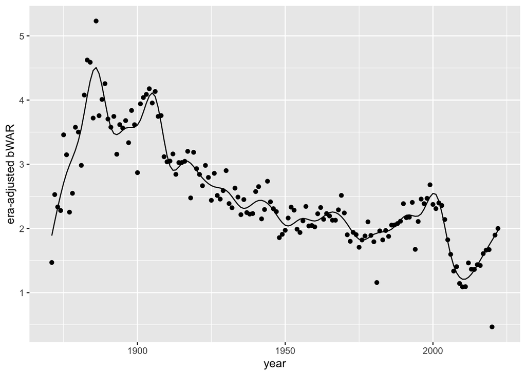

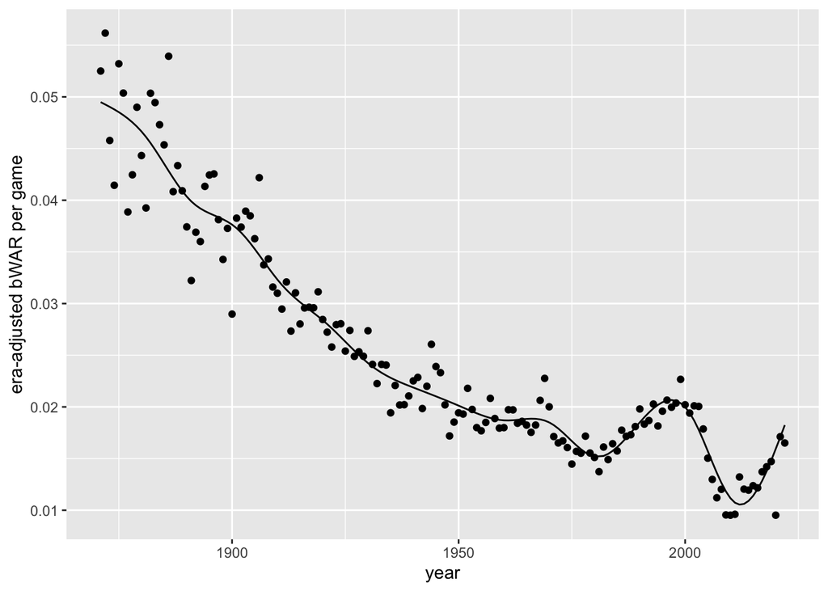

Then we also calculate the fWAR talent of a hypothetical 2022 hitter with 0 fWAR. Then, we compute his era-adjusted fWAR by mapping this hypothetical player to the other seasons from 1871 through 2021.

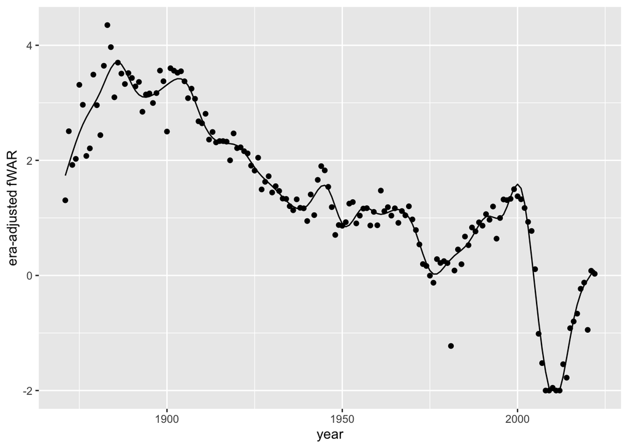

The figure above shows the era-adjusted fWAR values over time corresponding to a hypothetical batter with 0 fWAR in 2022 using the Full House Model. The fall in the mid-2000s corresponds to increase of MLB-eligible population. The problem of the sharp decline in era-adjusted fWAR values in the 1981 season can also be resolved when we look at the era-adjusted fWAR and era-adjusted fWAR per game of the hypothetical hitters from 2022 with 2 fWAR.

The two figures below show he era-adjusted fWAR and era-adjusted fWAR per game of the hypothetical hitters from 2022 with 2 fWAR.

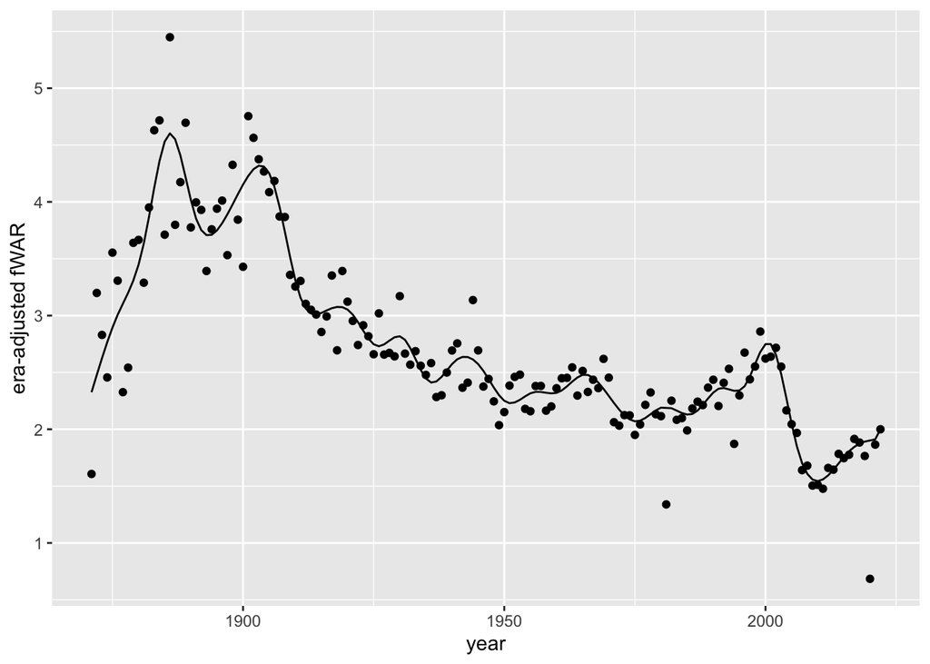

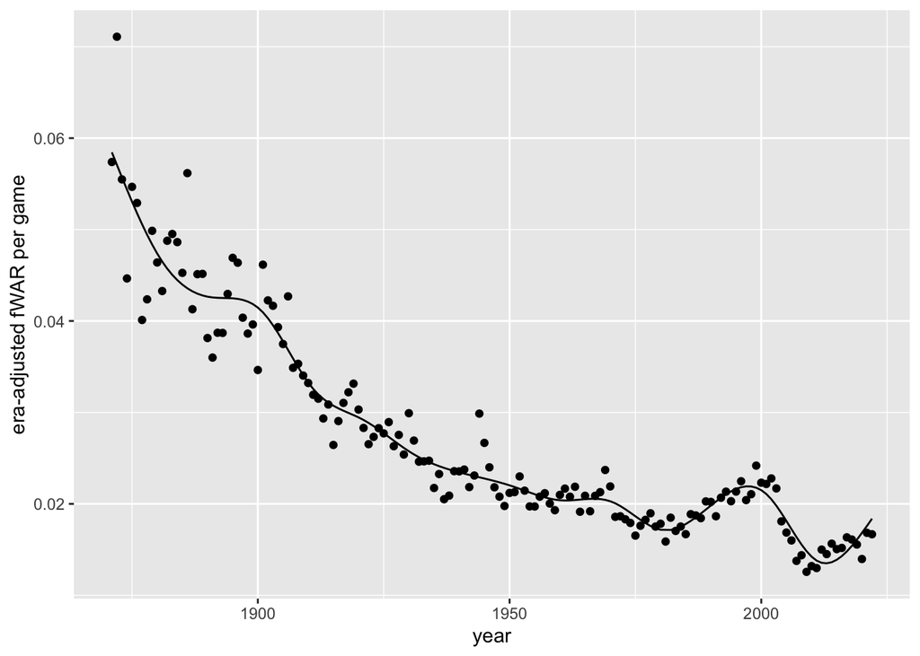

## Expansion Effect

It is actually supposed that the Major League’s expansion effect has a significant impact on how the talent scores vary over time and the magnitude of talent will be diluted with the expansion. However, after adding some hypothetical players who had poor performance in the early seasons, when there were fewer players, we discover that the real players did not much benefit from the adjustment of adding hypothetical players. Additionally, we make an effort to establish replacement player baselines throughout all seasons and adjust these baselines at the same level. However, the baselines we construct for every season are quite similar, and the talents of the players from earlier eras do not get much improved.

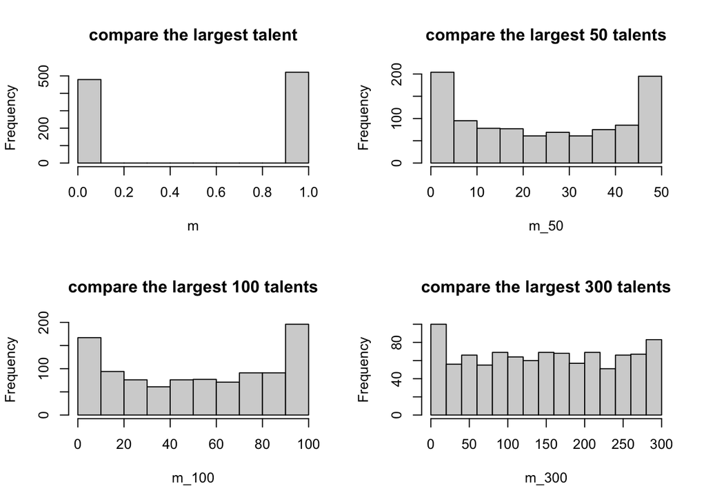

We also run another simulation to test the effect of season size. Instead of generating 600 components in the group 1, I generate 900 components and repeat the rest of the simulation. Then we have the similar results.

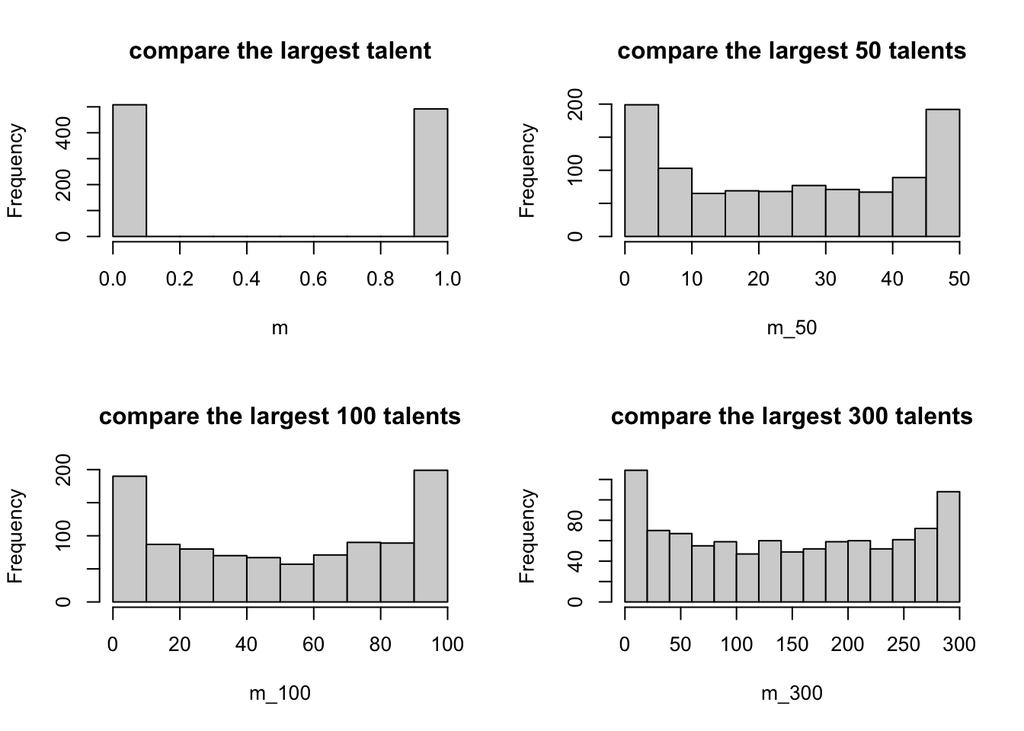

In this part, we compare the BA before and in the expansion seasons and see if there is a significant difference between them. The expansion seasons are collected from [Wikipedia](https://en.wikipedia.org/wiki/Major_League_Baseball) and they are 1879, 1892, 1900, 1901, 1961, 1962, 1969, 1977, 1993, and 1998. We compute the average and standard deviation of full-time batters’ BA before and in the expansion seasons and the results are shown below.

| yearID | mean | sd | yearID | mean | sd |
| --- | --- | --- | --- | --- | --- |
| 1878 | 0.281 | 0.043 | 1879 | 0.270 | 0.041 |
| 1891 | 0.264 | 0.027 | 1892 | 0.259 | 0.029 |
| 1899 | 0.293 | 0.037 | 1900 | 0.291 | 0.034 |
| 1900 | 0.291 | 0.034 | 1901 | 0.284 | 0.039 |
| 1960 | 0.268 | 0.025 | 1961 | 0.272 | 0.029 |
| 1961 | 0.272 | 0.029 | 1962 | 0.271 | 0.026 |
| 1968 | 0.250 | 0.027 | 1969 | 0.261 | 0.029 |
| 1976 | 0.264 | 0.030 | 1977 | 0.273 | 0.028 |
| 1992 | 0.265 | 0.026 | 1993 | 0.276 | 0.028 |
| 1997 | 0.276 | 0.027 | 1998 | 0.276 | 0.027 |

The average and standard error of the difference between the full-time batters’ BA before and in the expansion seasons are shown below.

| avg | se |
| --- | --- |
| -9e-04 | 0.0024288 |

We also show Willie Mays’s seasonal bWAR per game in his 22 years MLB career from 1951 to 1973 season except the 1953 season. The red dots represent the seasons that the MLB were experiencing the expansion. The result show that the expansion did not have any significant positive or negative effects on Willie Mays’s prime season or the tail of his career.

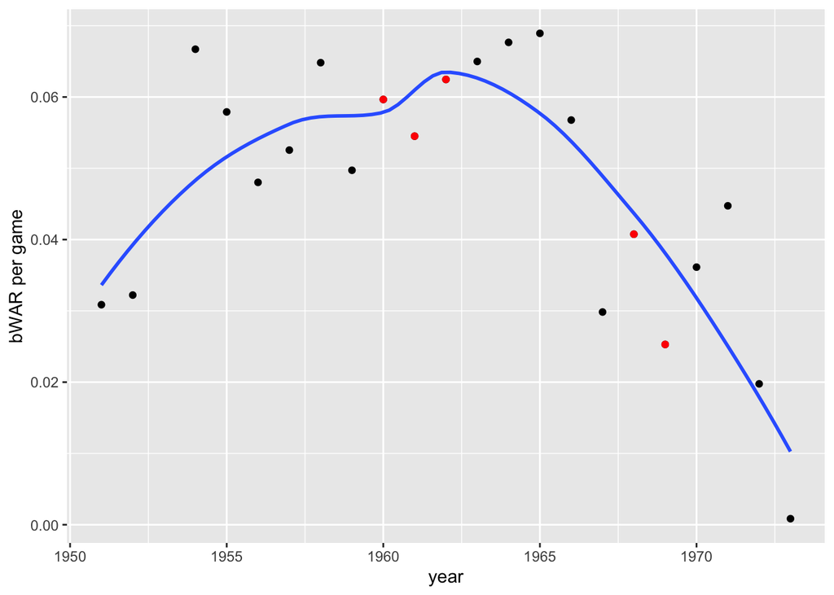

We also show Randy Johnson’s seasonal bWAR per game in his 22 years MLB career from 1988 to 2009 season. The red dots represent the seasons that the MLB were experiencing the expansion. The result show that the expansion did not have any significant positive or negative effects on Randy Johnson’s prime season.

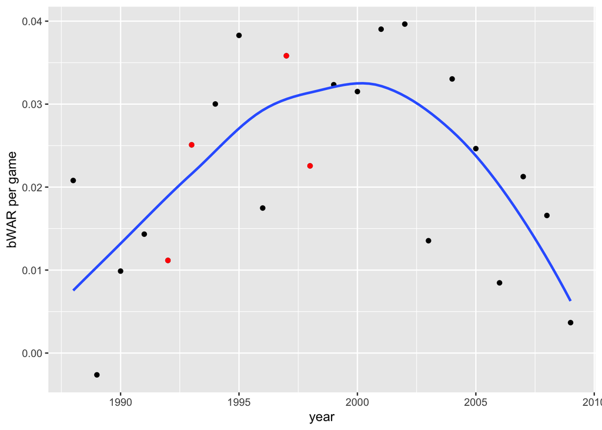

## Figure 3: 4 moments of BA in paper

This figure below shows that four statistical moments of the batting average distribution from 1871 to 2021 season. Points in red correspond to seasons surrounding the peak of WWII (1941-1946).

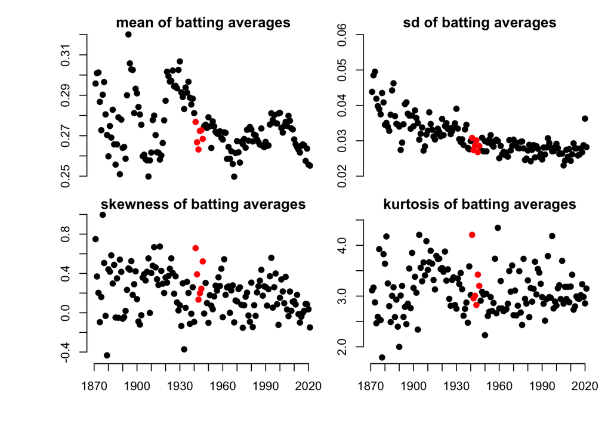

## Distribution Sensitity Analysis

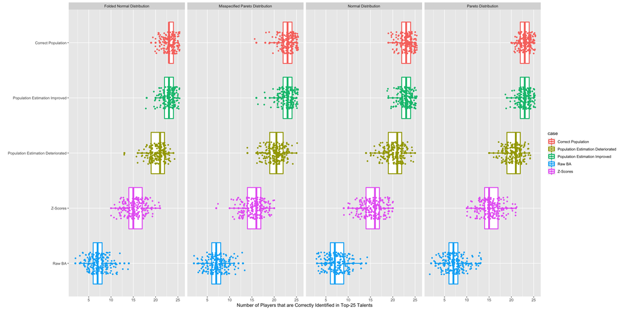

## Table 8: Comparsion between deteriorated estimation regime and Z-scores in the Supplementary materials.

|  | correct Pareto dist | incorrect Pareto dist | normal dist | folded normal dist |
| --- | --- | --- | --- | --- |
| beat or ties | 1 | 1 | 1.000 | 1 |
| strictly beat | 1 | 1 | 0.995 | 1 |

## Ranking Lists Using Different Talent Generating Process

In this section, we use different talent generating process to verify the robustness of the model.

The table below shows the top 25 bWAR players using four different talent generating process. The talent follows folded normal distribution, normal distribution, Pareto distribution with $\alpha = 3$ and Pareto distribution with $\alpha = 1.16$. Given that the ranking lists produced by the four separate generating processes are identical, we can say that our Full House model’s talent generating process is fairly robust.

| rank | standard normal | Folded normal (mu = 0, sigma = 1) | Pareto with alpha = 3 | Pareto with alpha = 1.16 |
| --- | --- | --- | --- | --- |
| 1 | Barry Bonds | Barry Bonds | Barry Bonds | Barry Bonds |
| 2 | Willie Mays | Willie Mays | Willie Mays | Willie Mays |
| 3 | Roger Clemens | Roger Clemens | Roger Clemens | Roger Clemens |
| 4 | Henry Aaron | Henry Aaron | Henry Aaron | Henry Aaron |
| 5 | Babe Ruth | Babe Ruth | Babe Ruth | Babe Ruth |
| 6 | Alex Rodriguez | Alex Rodriguez | Alex Rodriguez | Alex Rodriguez |
| 7 | Stan Musial | Stan Musial | Stan Musial | Stan Musial |
| 8 | Greg Maddux | Greg Maddux | Greg Maddux | Greg Maddux |
| 9 | Mike Schmidt | Mike Schmidt | Mike Schmidt | Mike Schmidt |
| 10 | Ty Cobb | Ty Cobb | Ty Cobb | Ty Cobb |
| 11 | Randy Johnson | Randy Johnson | Randy Johnson | Randy Johnson |
| 12 | Albert Pujols | Albert Pujols | Albert Pujols | Albert Pujols |
| 13 | Ted Williams | Ted Williams | Ted Williams | Ted Williams |
| 14 | Rickey Henderson | Rickey Henderson | Rickey Henderson | Rickey Henderson |
| 15 | Tom Seaver | Tom Seaver | Tom Seaver | Tom Seaver |
| 16 | Lefty Grove | Lefty Grove | Lefty Grove | Lefty Grove |
| 17 | Tris Speaker | Tris Speaker | Tris Speaker | Tris Speaker |
| 18 | Joe Morgan | Joe Morgan | Joe Morgan | Joe Morgan |
| 19 | Frank Robinson | Frank Robinson | Frank Robinson | Frank Robinson |
| 20 | Bert Blyleven | Bert Blyleven | Bert Blyleven | Bert Blyleven |
| 21 | Rogers Hornsby | Rogers Hornsby | Rogers Hornsby | Rogers Hornsby |
| 22 | Cal Ripken Jr | Cal Ripken Jr | Cal Ripken Jr | Cal Ripken Jr |
| 23 | Mel Ott | Mel Ott | Mel Ott | Mel Ott |
| 24 | Lou Gehrig | Lou Gehrig | Lou Gehrig | Lou Gehrig |
| 25 | Phil Niekro | Phil Niekro | Phil Niekro | Phil Niekro |

## Multiverse Analysis

### Batting Average

We will test four factors in our Full House Model and use batting average to illustrate it. These four factors are park-factor effect, population change, component distribution and season size effect. The table shows the value of the BA of Tony Gwynn in the 1997 season minus the BA of Ty Cobb in the 1911 season under different configurations before or after applying the smoothing and trimming method. The Park Factor column indicates whether we apply the park-factor adjustment to the BA. The Population column indicates the population changes we apply to the MLB-eligible population. The pre_int shows we add 10% for pre-integration seasons; The econ_effect shows we deduct 10% for the years prior to 1980 due to the economic effect; The normal shows we use the normal MLB-eligible population. The Distribution column indicates we use parametric distribution and non-parametric distribution to measure the BA in each season. The League Size column indicates we consider two different league sizes as the number of components in each season. The Historical shows we use historical league size as the number of components in each season. The Fixed shows that we compute the maximum number of components in every season and consider this value as the fixed number of components each season. The diff_after indicates the value of the BA of Tony Gwynn in the 1997 season minus the BA of Ty Cobb in the 1911 season under different configurations after applying the smoothing and trimming method. The diff_before indicates the value of the BA of Tony Gwynn in the 1997 season minus the BA of Ty Cobb in the 1911 season under different configurations before applying the smoothing and trimming method.

| PF | pops | para | league | diff_before | diff_after |
| --- | --- | --- | --- | --- | --- |
| YES | pre_int | para | historical | 0.018 | 0.007 |
| YES | pre_int | para | fixed | 0.007 | 0.002 |
| YES | pre_int | nonpara | historical | 0.035 | 0.027 |
| YES | pre_int | nonpara | fixed | 0.035 | 0.027 |
| YES | econ_effect | para | historical | 0.019 | 0.010 |
| YES | econ_effect | para | fixed | 0.008 | 0.004 |
| YES | econ_effect | nonpara | historical | 0.038 | 0.030 |
| YES | econ_effect | nonpara | fixed | 0.038 | 0.030 |
| YES | normal | para | historical | 0.018 | 0.007 |
| YES | normal | para | fixed | 0.007 | 0.004 |
| YES | normal | nonpara | historical | 0.038 | 0.028 |
| YES | normal | nonpara | fixed | 0.038 | 0.028 |
| NO | pre_int | para | historical | 0.003 | -0.007 |
| NO | pre_int | para | fixed | 0.000 | -0.008 |
| NO | pre_int | nonpara | historical | 0.028 | 0.020 |
| NO | pre_int | nonpara | fixed | 0.028 | 0.020 |
| NO | econ_effect | para | historical | 0.005 | -0.005 |
| NO | econ_effect | para | fixed | 0.002 | -0.006 |
| NO | econ_effect | nonpara | historical | 0.030 | 0.021 |
| NO | econ_effect | nonpara | fixed | 0.030 | 0.021 |
| NO | normal | para | historical | 0.004 | -0.007 |
| NO | normal | para | fixed | 0.001 | -0.006 |
| NO | normal | nonpara | historical | 0.029 | 0.020 |
| NO | normal | nonpara | fixed | 0.029 | 0.020 |

### bWAR

We also use bWAR to test the effect of population change and season size in our Full House Model. The table shows the value of the career bWAR of Willie Mays minus the career bWAR of Babe Ruth under different configurations before and after applying the smoothing and trimming method. The pops column indicates the population changes we apply to the MLB-eligible population. The pre_int shows we add 10% for pre-integration seasons; The econ_effect shows we deduct 10% for the years prior to 1980 due to the economic effect; The normal shows we use the normal MLB-eligible population. The league column indicates we consider two different league sizes as the number of components in each season. The historical shows we use historical league size as the number of components in each season. The fixed shows that we compute the maximum number of components in every season and consider this value as the fixed number of components each season. The diff_after indicates the value of the career bWAR of Willie Mays minus the career bWAR of Babe Ruth under different configurations after applying the smoothing and trimming method. The diff_before indicates the value of the career bWAR of Willie Mays minus the career bWAR of Babe Ruth under different configurations before applying the smoothing and trimming method.

| pops | league | diff_after | diff_before |
| --- | --- | --- | --- |
| pre_int | historical | 2.46 | 7.69 |
| pre_int | fixed | 2.39 | 7.72 |
| econ_effect | historical | 8.96 | 14.38 |
| econ_effect | fixed | 8.77 | 14.23 |
| normal | historical | 5.19 | 10.52 |
| normal | fixed | 5.11 | 10.51 |

## Z-scores for 1997 Gwynn and 1911 Cobb from park factor adjusted BAs and regular unadjusted BAs.

| name | year | zscore_BA | normality_BA | zscore_obs_BA | normality_obs_BA |
| --- | --- | --- | --- | --- | --- |
| Ty Cobb | 1911 | 3.425657 | 0.1625329 | 3.460512 | 0.0436831 |
| Tony Gwynn | 1997 | 3.822984 | 0.0167243 | 3.339753 | 0.1744079 |

## Fixed MLB-eligible population for all seasons.

In order to show how the MLB-eligible population change our rankings, we set 1 million as the MLB-eligible population for every season and see what the rankings look like.

The following tables display the results with the fixed MLB-eligible population.

Top 25 combined bWAR and fWAR rankings:

| ebWAR | efWAR |
| --- | --- |
| Babe Ruth | Babe Ruth |
| Cap Anson | Ty Cobb |
| Ty Cobb | Cap Anson |
| Barry Bonds | Cy Young |
| Willie Mays | Barry Bonds |
| Cy Young | Willie Mays |
| Roger Clemens | Roger Clemens |
| Henry Aaron | Honus Wagner |
| Honus Wagner | Henry Aaron |
| Walter Johnson | Walter Johnson |
| Tris Speaker | Tris Speaker |
| Stan Musial | Stan Musial |
| Eddie Collins | Eddie Collins |
| Nap Lajoie | Greg Maddux |
| Rogers Hornsby | Ted Williams |
| Lefty Grove | Rogers Hornsby |
| Ted Williams | Mel Ott |
| Mel Ott | Nap Lajoie |
| Alex Rodriguez | Lefty Grove |
| Warren Spahn | Nolan Ryan |
| Greg Maddux | Randy Johnson |
| Lou Gehrig | Lou Gehrig |
| Rickey Henderson | Pete Alexander |
| Jim O Rourke | Mike Schmidt |
| Pete Alexander | Jim O Rourke |

Top 25 BA, OBP and HR leaders

| name | BA | name | OBP | name | HR |
| --- | --- | --- | --- | --- | --- |
| Ty Cobb | 0.348 | Ross Barnes | 0.469 | Henry Aaron | 737 |
| Ross Barnes | 0.346 | Billy Hamilton | 0.469 | Babe Ruth | 737 |
| Tony Gwynn | 0.343 | John McGraw | 0.468 | Cap Anson | 668 |
| Dan Brouthers | 0.341 | Babe Ruth | 0.468 | Barry Bonds | 665 |
| Billy Hamilton | 0.336 | Ted Williams | 0.466 | Albert Pujols | 626 |
| Cal McVey | 0.333 | Roy Thomas | 0.450 | Willie Mays | 624 |
| Rod Carew | 0.332 | Lou Gehrig | 0.449 | Stan Musial | 601 |
| Ed Delahanty | 0.332 | Dan Brouthers | 0.446 | Reggie Jackson | 591 |
| Shoeless Joe Jackson | 0.332 | George Gore | 0.446 | Frank Robinson | 589 |
| Nap Lajoie | 0.332 | Mickey Mantle | 0.442 | Jimmie Foxx | 588 |
| Joe DiMaggio | 0.331 | Cap Anson | 0.435 | Honus Wagner | 579 |
| Rogers Hornsby | 0.331 | Barry Bonds | 0.435 | Jim O Rourke | 570 |
| Cap Anson | 0.330 | Ty Cobb | 0.435 | Mike Schmidt | 567 |
| Lou Gehrig | 0.329 | Mike Trout | 0.434 | Mickey Mantle | 563 |
| Sam Thompson | 0.329 | Eddie Collins | 0.433 | Lou Gehrig | 557 |
| Dale Mitchell | 0.328 | Cupid Childs | 0.431 | Ted Williams | 556 |
| Ted Williams | 0.328 | Max Bishop | 0.430 | Ty Cobb | 554 |
| Stan Musial | 0.327 | Roger Connor | 0.430 | Rogers Hornsby | 553 |
| Bill Terry | 0.327 | Ed Williamson | 0.430 | Harmon Killebrew | 550 |
| Roberto Clemente | 0.326 | Frank Chance | 0.429 | Alex Rodriguez | 548 |
| Babe Ruth | 0.326 | Ed Delahanty | 0.429 | Willie Stargell | 548 |
| Tris Speaker | 0.326 | Rogers Hornsby | 0.428 | Eddie Mathews | 543 |
| Honus Wagner | 0.326 | Tris Speaker | 0.428 | Willie McCovey | 543 |
| Deacon White | 0.326 | John Clapp | 0.427 | Mel Ott | 530 |
| Jesse Burkett | 0.325 | Joey Votto | 0.427 | Roger Connor | 528 |

Top 25 bWAR and fWAR batting leaders

| name | ebWAR | name | efWAR |
| --- | --- | --- | --- |
| Cap Anson | 160.09 | Ty Cobb | 150.57 |
| Ty Cobb | 159.90 | Cap Anson | 149.65 |
| Barry Bonds | 155.96 | Barry Bonds | 146.08 |
| Willie Mays | 154.38 | Willie Mays | 142.96 |
| Babe Ruth | 151.81 | Babe Ruth | 141.85 |
| Henry Aaron | 145.09 | Honus Wagner | 139.47 |
| Honus Wagner | 144.22 | Henry Aaron | 137.40 |
| Tris Speaker | 141.89 | Tris Speaker | 133.13 |
| Stan Musial | 137.73 | Stan Musial | 130.10 |
| Eddie Collins | 133.70 | Eddie Collins | 124.78 |
| Nap Lajoie | 125.08 | Ted Williams | 119.96 |
| Rogers Hornsby | 124.49 | Rogers Hornsby | 117.73 |
| Ted Williams | 123.67 | Mel Ott | 116.15 |
| Mel Ott | 123.13 | Nap Lajoie | 114.57 |
| Alex Rodriguez | 114.42 | Lou Gehrig | 108.11 |
| Lou Gehrig | 112.24 | Mike Schmidt | 107.03 |
| Rickey Henderson | 112.15 | Jim O Rourke | 106.97 |
| Jim O Rourke | 112.05 | Mickey Mantle | 106.64 |
| Roger Connor | 110.84 | Alex Rodriguez | 105.67 |
| Mike Schmidt | 110.79 | Rickey Henderson | 105.63 |
| George Davis | 110.00 | Frank Robinson | 105.03 |
| Mickey Mantle | 109.72 | Roger Connor | 104.11 |
| Frank Robinson | 109.30 | George Davis | 103.06 |
| Carl Yastrzemski | 104.08 | Jimmie Foxx | 103.05 |
| Joe Morgan | 103.42 | Carl Yastrzemski | 100.74 |

Top 25 IP, ERA, SO leaders

| name | IP | name | ERA | name | SO |
| --- | --- | --- | --- | --- | --- |
| Greg Maddux | 5653 | Tommy Bond | 2.30 | Nolan Ryan | 6040 |
| Roger Clemens | 5440 | Al Spalding | 2.31 | Walter Johnson | 5072 |
| Nolan Ryan | 5318 | Mariano Rivera | 2.34 | Randy Johnson | 5050 |
| Cy Young | 5140 | Tim Keefe | 2.36 | Roger Clemens | 4748 |
| Warren Spahn | 5139 | Amos Rusie | 2.44 | Steve Carlton | 4353 |
| Phil Niekro | 5079 | Jim McCormick | 2.46 | Cy Young | 4133 |
| Don Sutton | 5073 | Lefty Grove | 2.47 | Bert Blyleven | 3772 |
| Gaylord Perry | 5023 | Old Hoss Radbourn | 2.49 | Tom Seaver | 3701 |
| Steve Carlton | 4976 | John Clarkson | 2.50 | Don Sutton | 3616 |
| Walter Johnson | 4928 | Cy Young | 2.52 | Bob Feller | 3519 |
| Tom Glavine | 4921 | Hoyt Wilhelm | 2.53 | Warren Spahn | 3507 |
| Bert Blyleven | 4881 | Walter Johnson | 2.54 | Gaylord Perry | 3506 |
| Randy Johnson | 4725 | Kid Nichols | 2.54 | Pete Alexander | 3486 |
| Tommy John | 4587 | Bobby Mathews | 2.55 | Greg Maddux | 3432 |
| Tom Seaver | 4586 | Dizzy Dean | 2.56 | Phil Niekro | 3428 |
| Jamie Moyer | 4508 | Clayton Kershaw | 2.56 | Lefty Grove | 3407 |
| Early Wynn | 4498 | Ed Walsh | 2.57 | Early Wynn | 3269 |
| Robin Roberts | 4437 | Mickey Welch | 2.57 | Red Ruffing | 3254 |
| Pete Alexander | 4358 | Addie Joss | 2.58 | Bobo Newsom | 3193 |
| Frank Tanana | 4201 | Pete Alexander | 2.61 | Fergie Jenkins | 3161 |
| Fergie Jenkins | 4200 | Pud Galvin | 2.61 | John Smoltz | 3154 |
| CC Sabathia | 4175 | Brandon Webb | 2.62 | Pedro Martinez | 3096 |
| Dennis Martinez | 4174 | Charlie Buffinton | 2.63 | Christy Mathewson | 3094 |
| Red Ruffing | 4112 | Noodles Hahn | 2.63 | Curt Schilling | 3064 |
| Jim Kaat | 4066 | Carl Hubbell | 2.64 | Dazzy Vance | 3047 |

Top 25 bWAR and fWAR pitching leaders

| name | ebWAR | name | efWAR |
| --- | --- | --- | --- |
| Cy Young | 147.01 | Cy Young | 149.46 |
| Roger Clemens | 146.12 | Roger Clemens | 140.29 |
| Walter Johnson | 143.72 | Walter Johnson | 133.89 |
| Lefty Grove | 124.35 | Greg Maddux | 121.32 |
| Warren Spahn | 113.10 | Lefty Grove | 113.41 |
| Greg Maddux | 112.77 | Nolan Ryan | 110.38 |
| Pete Alexander | 111.58 | Randy Johnson | 108.83 |
| Randy Johnson | 111.07 | Pete Alexander | 107.09 |
| Tom Seaver | 105.18 | Bert Blyleven | 102.91 |
| Bert Blyleven | 101.22 | Steve Carlton | 101.47 |
| Robin Roberts | 99.67 | Gaylord Perry | 97.63 |
| Kid Nichols | 99.51 | Christy Mathewson | 95.06 |
| Christy Mathewson | 98.15 | Tom Seaver | 91.51 |
| Phil Niekro | 97.25 | Warren Spahn | 90.16 |
| Gaylord Perry | 95.47 | Kid Nichols | 88.31 |
| Steve Carlton | 91.23 | Robin Roberts | 85.69 |
| Nolan Ryan | 89.84 | Don Sutton | 85.17 |
| Pedro Martinez | 85.47 | Bob Gibson | 80.53 |
| Mike Mussina | 84.57 | Mike Mussina | 80.18 |
| Curt Schilling | 82.62 | Pedro Martinez | 80.13 |
| Bob Gibson | 82.44 | Phil Niekro | 79.36 |
| Tom Glavine | 81.82 | Tommy John | 79.33 |
| Ted Lyons | 80.83 | John Smoltz | 79.28 |
| Early Wynn | 80.50 | Justin Verlander | 78.78 |
| Fergie Jenkins | 80.23 | Fergie Jenkins | 78.02 |

## MLB-eligible population Calculation

Based on the MLB-eligible population computed from the supplementary materials, we are able to obtain the proportion of the MLB-eligible population before 1950 in different season spans. For example, we would like to calculate the proportion of the MLB-eligible population before 1950 from 1871 to 2005. Given the MLB-eligible population are evenly distribution from the age 20 to 29, the cumulative MLB-eligible males aged 20 to 29 from 1871 to 1879 is equal to 90% of the MLB-eligible population in 1871. Similarly, the cumulative MLB-eligible males aged 20 to 29 from 2000 to 2005 is equal to 50% of the MLB-eligible population in 2005. The code below shows how to compute the proportion of the MLB-eligible population before 1950 from 1871 to 2005.

```r
# MLBpops contains the MLB-eligible population from 1871 to 2022
n <- MLBpops[MLBpops$yearID %in% c(1871, seq(1880, 2000, 10), 2005),]
p <- n
p$population[1] <- n$population[1] /10*9
p$population[15] <- n$population[15] /2
o <- p %>% mutate(population = round(population, 2)) %>%
  mutate(cpp = round(cumsum(p$population)/(sum(p$population)), 3))

kable(o[o$yearID == 1950,c(1,3)]) %>%
  kable_styling(bootstrap_options = c("striped", "hover", "condensed", "responsive"))
```

| yearID | cpp |
| --- | --- |
| 1950 | 0.292 |

## Table 9: bWAR rankings from Full House Model using different talent generating function in the Supplementary materials.

| rank | standard normal | Folded normal (mu = 0, sigma = 1) | Pareto with alpha = 3 | Pareto with alpha = 1.16 |
| --- | --- | --- | --- | --- |
| 1 | Barry Bonds | Barry Bonds | Barry Bonds | Barry Bonds |
| 2 | Willie Mays | Willie Mays | Willie Mays | Willie Mays |
| 3 | Roger Clemens | Roger Clemens | Roger Clemens | Roger Clemens |
| 4 | Henry Aaron | Henry Aaron | Henry Aaron | Henry Aaron |
| 5 | Babe Ruth | Babe Ruth | Babe Ruth | Babe Ruth |
| 6 | Alex Rodriguez | Alex Rodriguez | Alex Rodriguez | Alex Rodriguez |
| 7 | Stan Musial | Stan Musial | Stan Musial | Stan Musial |
| 8 | Greg Maddux | Greg Maddux | Greg Maddux | Greg Maddux |
| 9 | Mike Schmidt | Mike Schmidt | Mike Schmidt | Mike Schmidt |
| 10 | Ty Cobb | Ty Cobb | Ty Cobb | Ty Cobb |
| 11 | Randy Johnson | Randy Johnson | Randy Johnson | Randy Johnson |
| 12 | Albert Pujols | Albert Pujols | Albert Pujols | Albert Pujols |
| 13 | Ted Williams | Ted Williams | Ted Williams | Ted Williams |
| 14 | Rickey Henderson | Rickey Henderson | Rickey Henderson | Rickey Henderson |
| 15 | Tom Seaver | Tom Seaver | Tom Seaver | Tom Seaver |
| 16 | Lefty Grove | Lefty Grove | Lefty Grove | Lefty Grove |
| 17 | Tris Speaker | Tris Speaker | Tris Speaker | Tris Speaker |
| 18 | Joe Morgan | Joe Morgan | Joe Morgan | Joe Morgan |
| 19 | Frank Robinson | Frank Robinson | Frank Robinson | Frank Robinson |
| 20 | Bert Blyleven | Bert Blyleven | Bert Blyleven | Bert Blyleven |
| 21 | Rogers Hornsby | Rogers Hornsby | Rogers Hornsby | Rogers Hornsby |
| 22 | Cal Ripken Jr | Cal Ripken Jr | Cal Ripken Jr | Cal Ripken Jr |
| 23 | Mel Ott | Mel Ott | Mel Ott | Mel Ott |
| 24 | Lou Gehrig | Lou Gehrig | Lou Gehrig | Lou Gehrig |
| 25 | Phil Niekro | Phil Niekro | Phil Niekro | Phil Niekro |

## Table 10: BA of Tony Gwynn in the 1997 season minus the BA of Ty Cobb in the 1911 season under different configurations before or after applying the smoothing and trimming method in the Supplementary materials.

The table shows the value of the BA of Tony Gwynn in the 1997 season minus the BA of Ty Cobb in the 1911 season under different configurations before or after applying the smoothing and trimming method. The Park Factor column indicates whether we apply the park-factor adjustment to the BA. The Population column indicates the population changes we apply to the MLB-eligible population. The Increase shows we add 10% for pre-integration seasons; The Decrease shows we deduct 10% for the years prior to 1980 due to the economic effect; The Normal shows we use the normal MLB-eligible population. The Distribution column indicates we use parametric distribution and non-parametric distribution to measure the BA in each season. The League Size column indicates we consider two different league sizes as the number of components in each season. The Historical shows we use historical league size as the number of components in each season. The Fixed shows that we compute the maximum number of components in every season and consider this value as the fixed number of components each season. The Difference after indicates the value of the BA of Tony Gwynn in the 1997 season minus the BA of Ty Cobb in the 1911 season under different configurations after applying the smoothing and trimming method. The Difference before indicates the value of the BA of Tony Gwynn in the 1997 season minus the BA of Ty Cobb in the 1911 season under different configurations before applying the smoothing and trimming method.

| Park Factor | Population | Distribution | League Size | Difference after | Difference before |
| --- | --- | --- | --- | --- | --- |
| YES | pre_int | para | historical | 0.007 | 0.018 |
|  |  |  | fixed | 0.002 | 0.007 |
|  |  | nonpara | historical | 0.027 | 0.035 |
|  |  |  | fixed | 0.027 | 0.035 |
|  | econ_effect | para | historical | 0.010 | 0.019 |
|  |  |  | fixed | 0.004 | 0.008 |
|  |  | nonpara | historical | 0.030 | 0.038 |
|  |  |  | fixed | 0.030 | 0.038 |
|  | normal | para | historical | 0.007 | 0.018 |
|  |  |  | fixed | 0.004 | 0.007 |
|  |  | nonpara | historical | 0.028 | 0.038 |
|  |  |  | fixed | 0.028 | 0.038 |
| NO | pre_int | para | historical | -0.007 | 0.003 |
|  |  |  | fixed | -0.008 | 0.000 |
|  |  | nonpara | historical | 0.020 | 0.028 |
|  |  |  | fixed | 0.020 | 0.028 |
|  | econ_effect | para | historical | -0.005 | 0.005 |
|  |  |  | fixed | -0.006 | 0.002 |
|  |  | nonpara | historical | 0.021 | 0.030 |
|  |  |  | fixed | 0.021 | 0.030 |
|  | normal | para | historical | -0.007 | 0.004 |
|  |  |  | fixed | -0.006 | 0.001 |
|  |  | nonpara | historical | 0.020 | 0.029 |
|  |  |  | fixed | 0.020 | 0.029 |

## Table 11: career BA of Tony Gwynn minus the career BA of Ty Cobb under different configurations before and after applying the smoothing and trimming method in the Supplementary materials.

The table shows the value of the career BA of Tony Gwynn minus the career BA of Ty Cobb under different configurations before and after applying the smoothing and trimming method. The Park Factor column indicates whether we apply the park-factor adjustment to the BA. The Population column indicates the population changes we apply to the MLB-eligible population. The Increase shows we add 10% for pre-integration seasons; The Decrease shows we deduct 10% for the years prior to 1980 due to the economic effect; The Normal shows we use the normal MLB-eligible population. The Distribution column indicates we use parametric distribution and non-parametric distribution to measure the BA in each season. The League Size column indicates we consider two different league sizes as the number of components in each season. The Historical shows we use historical league size as the number of components in each season. The Fixed shows that we compute the maximum number of components in every season and consider this value as the fixed number of components each season. The Difference after indicates the value of the career BA of Tony Gwynn minus the career BA of Ty Cobb under different configurations after the smoothing and trimming method. The Difference before indicates the value of the career BA of Tony Gwynn minus the career BA of Ty Cobb under different configurations before the smoothing and trimming method.

| Park Factor | Population | Distribution | League Size | Difference before | Difference after |
| --- | --- | --- | --- | --- | --- |
| YES | pre_int | para | historical | 0.006 | 0.009 |
|  |  |  | fixed | 0.002 | 0.005 |
|  |  | nonpara | historical | 0.020 | 0.024 |
|  |  |  | fixed | 0.020 | 0.024 |
|  | econ_effect | para | historical | 0.009 | 0.012 |
|  |  |  | fixed | 0.004 | 0.008 |
|  |  | nonpara | historical | 0.023 | 0.027 |
|  |  |  | fixed | 0.023 | 0.027 |
|  | normal | para | historical | 0.007 | 0.011 |
|  |  |  | fixed | 0.003 | 0.007 |
|  |  | nonpara | historical | 0.022 | 0.026 |
|  |  |  | fixed | 0.022 | 0.026 |
| NO | pre_int | para | historical | -0.002 | 0.001 |
|  |  |  | fixed | -0.004 | -0.001 |
|  |  | nonpara | historical | 0.011 | 0.015 |
|  |  |  | fixed | 0.011 | 0.015 |
|  | econ_effect | para | historical | 0.000 | 0.004 |
|  |  |  | fixed | -0.002 | 0.002 |
|  |  | nonpara | historical | 0.014 | 0.018 |
|  |  |  | fixed | 0.014 | 0.018 |
|  | normal | para | historical | -0.001 | 0.003 |
|  |  |  | fixed | -0.003 | 0.000 |
|  |  | nonpara | historical | 0.013 | 0.017 |
|  |  |  | fixed | 0.013 | 0.017 |

## Table 12: career bWAR of Willie Mays minus the career bWAR of Babe Ruth under different configurations before and after applying the smoothing and trimming method in the Supplementary materials.

The table shows the value of career bWAR of Willie Mays minus the career bWAR of Babe Ruth under different configurations before and after applying the smoothing and trimming method. The Population column indicates the population changes we apply to the MLB-eligible population. The Increase shows we add 10% for pre-integration seasons; The Decrease shows we deduct 10% for the years prior to 1980 due to the economic effect; The Normal shows we use the normal MLB-eligible population. The League Size column indicates we consider two different league sizes as the number of components in each season. The Historical shows we use historical league size as the number of components in each season. The Fixed shows that we compute the maximum number of components in every season and consider this value as the fixed number of components each season. The Difference after indicates the value of the career bWAR of Willie Mays minus the career bWAR of Babe Ruth under different configurations after applying the smoothing and trimming method. The Difference before indicates the value of the career bWAR of Willie Mays minus the career bWAR of Babe Ruth under different configurations before applying the smoothing and trimming method.

[output not shown]